# Dead labor: classed, gendered, and racialized mortality inequities in the United States

-

September 2022

- Overview:
  - Descriptive analyses of class and mortality in the cross-sectional 1986-2018 NHIS with mortality follow-up through the end of 2019. Survival curves and Cox models are minimally adjusted (age, gender, and year) using IPW unless otherwise noted.
- Coding of classes:
  - Incorporated business owners (IBOs, loosely analogous to capitalists) are those who are self-employed in an incorporated business
  - Unincorporated business owners (UBOs, loosely analogous to the petit bourgeoisie) are those who are self-employed in an unincorporated business or working without pay in a family business/farm (very few people in the latter)
  - Managers (mgrs) are those who are not self-employed but who are employed and who have an “executive, administrative, or managerial” occupation
  - Workers (wrks) are those who are unemployed/“not employed” (few people) OR who are employed but do not have a management occupation
  - Not in the labor force (NLFs) are those who are “not in the labor force”
- Useful references regarding IBOs vs UBOs:
  - Nuts and bolts:
    - https://smallbusiness.chron.com/difference-between-incorporated-unincorporated-businesses-57463.html
    - https://www.upcounsel.com/is-an-llc-incorporated-or-unincorporated
    - https://www.uschamber.com/co/start/strategy/sole-proprietorship-vs-incorporation
    - https://portal.311.nyc.gov/article/?kanumber=KA-03067: states LLCs are unincorporated (also stated elsewhere online)
  - Demographics:
    - https://www.pewresearch.org/social-trends/2015/10/22/three-in-ten-u-s-jobs-are-held-by-the-self-employed-and-the-workers-they-hire/
    - https://www.bls.gov/opub/mlr/2010/09/art2full.pdf
    - https://www.census.gov/content/dam/Census/library/working-papers/2018/demo/SEHSD-WP2018-28.pdf
- General notes:
  - Don’t think it makes sense to incorporate income into the regression analyses (e.g., mediation), even just as a sensitivity analysis. The ‘decent’ income data is only available from 1997-2018, and even that data is categorical and top-coded. Moreover, the top-coding changed over time (75k from 1997-2006; 100k from 2007-2008; and 115k from 2009-2018). Thus, unless we extrapolated or imputed beyond the top-codes, we’d have to use a categorical income variable with a max category of $75k+, which is well below the third quartile of family incomes after adjusting for inflation (and below IBOs’ and mgrs’ median incomes). The original income data also contains a lot of missingness, and NHIS recommends it be analyzed via imputation methods, which would complicate our approach considerably.
  - Too few respondents in minoritized racial/ethnic groups who are IBOs to break out minoritized racial/ethnic groups into finer subgroups (survival estimates very unstable)
  - Numemps (number of employees at work) only available from 2001-2018 - would be alternative way to classify business owners but I think its categories are too imprecise and limited availability is problematic
  - Can’t identify “chief executives, general and operative managers, and legislators” until 2004 because of limited occupation data before then (can never identify “chief executives” alone, who we’ve classified as IBOs in the past)
  - Useful citation regarding occupation and mortality in NHIS: https://www.sciencedirect.com/science/article/pii/S0091743520301535 and http://paa2019.populationassociation.org/uploads/190718
- Methods notes:
  - Monitor release of vintage-specific weights (https://forum.ipums.org/t/weighting-when-using-pooling-1986-2014-nhis-linked-mortality-files/4486/12)
  - When robust=T, weights are treated properly by survfit and coxph functions (as probability or sampling weights rather than frequency weights)
  - Citations for IPW and survey weighting approach: https://www.ncbi.nlm.nih.gov/labs/pmc/articles/PMC5802372/ and https://journals.sagepub.com/doi/full/10.1177/0193841X20938497

```r
library(dplyr)
library(data.table)
library(here)
library(survival)
library(rms)
library(broom)
library(Rcpp)
library(survey)
library(kableExtra)
library(tableone)
library(survminer)
library(ipw)
library(directlabels)
library(RColorBrewer)
library(patchwork)
library(cobalt)
library(naniar)
library(ggmosaic)
library(multcomp)
options(scipen=999)
options(knitr.kable.NA = '')

#load ipums data
dat <- fread(here('ipums_dat_1986_2018.csv'))

#make all variable names lowercase
#sort data by nhispid to keep results consistent across runs, as output from ipw package is (very minorly) affected by observation order
dat %>%
  rename_all(tolower) %>%
  arrange(nhispid) -> dat

#####exclusions
#exclude those outside age ranges (age has 0.09% missing)
#exclude those ineligible for mortality follow-up and those <25 or 65+ and those who aren't sample adults from 1997-on (occ1995 and classwk not available for others after that time); #note, from 2015-2018, only sample adult and sample child participants were eligible for mortality follow-up
#exclude 1997-2000, when there's no data on whether business is incorporated or not
#we'll exclude 1992 Hispanic oversample (only 3517 additional respondents) (per advice of IPUMS) separately, as we want to include them in sensitivity analyses
dat %>%
  filter((age>=25 & age<65) & mortelig==1 & (is.na(astatflg) | astatflg==1) & (year<1997 | (year>2000))) -> dat_sub

#make variables
dat_sub %>%
  mutate_at(.vars=(vars(-c(mortucod, mortwt, mortwtsa, psu, strata, nhispid, nhishid))),
            ~ifelse(. %in% c(91, 96, 97, 98, 99, 970, 980, 990, 997, 999, 7777, 8888, 9998, 9999), NA, .)) %>%
  mutate(classwk2=ifelse(classwk2 %in% (7:9), NA, classwk2), #these are real values in some other variables so we'll reset them here
         jobsecincorp=ifelse(jobsecincorp %in% (7:9), NA, jobsecincorp),
         racesr=ifelse(racesr==900, NA, racesr),
         lamtwrk=ifelse(lamtwrk %in% 7:9, NA, lamtwrk)) %>%
  #per IPUMS's advice, use mortwt from 1986-1996 and mortwtsa from 1997-on: https://forum.ipums.org/t/weighting-when-using-pooling-1986-2014-nhis-linked-mortality-files/4486
  mutate(mortwt_f=ifelse(year<=1996, mortwt, mortwtsa),
         hispanic_oversample=ifelse((year==1992 & substr(nhispid, 1, 4)==1991), 1, 0),
         int_year_fin=ifelse(year<2001, year, #1986-1996, separate interview year unavailable
                             ifelse(year>=2001 & !is.na(intervwyr), intervwyr, year)), #if interview year is missing (<0.1%), assume it happened in survey-wave year (true in >99% of cases)
         dead=ifelse(mortstat==1, 1, 0),
         time=ifelse(dead==0, 2020 - int_year_fin, mortdody + 1 - int_year_fin), #deaths thru end of 2019, ie, 2020; assume deaths occurred at end of each year (1986 deaths occurred at end of 1986, ie, 1987)
         dead_86_96_05=ifelse(int_year_fin>1996, NA, #time and death indicators for 1986-1996 panel
                              ifelse(int_year_fin<=1996 & (is.na(mortdody) | mortdody>2004), 0,
                                    ifelse(int_year_fin<=1996 & mortdody<=2004, 1, NA))),
         time_86_96_05=ifelse(int_year_fin>1996, NA,
                              ifelse(dead_86_96_05==1, mortdody + 1 - int_year_fin,
                                     ifelse(dead_86_96_05==0, 2005-int_year_fin, NA))),
         race=ifelse(racesr==100, "White",
                     ifelse(racesr==200, "Black", "Other")),
         hispeth_bin=ifelse(hispeth!=10, 1, 0),
         race_h=factor(ifelse(hispeth!=10, "Hispanic",
                              ifelse(hispeth==10 & race=="White", "NH white",
                                     ifelse(hispeth==10 & race=="Black", "NH black", "NH other"))), levels=c("NH white", "NH black", "Hispanic", "NH other")),
         poc=ifelse(race_h=="NH white", "NH white", "POC"),
         sex=ifelse(sex==1, "male", "female"),
         race_h_sex=factor(ifelse(race_h=="NH white" & sex=="male", "NH white men",
                                  ifelse(race_h=="NH white" & sex=="female", "NH white women",
                                         ifelse(race_h=="NH black" & sex=="male", "NH black men",
                                                ifelse(race_h=="NH black" & sex=="female", "NH black women",
                                                       ifelse(race_h=="Hispanic" & sex=="male", "Hispanic men",
                                                              ifelse(race_h=="Hispanic" & sex=="female", "Hispanic women",
                                                                     ifelse(race_h=="NH other" & sex=="male", "NH other men", "NH other women"))))))),
                           levels=c("NH white men", "NH white women", "NH black men", "NH black women", "Hispanic men", "Hispanic women", "NH other men", "NH other women")),
         educ=factor(ifelse(educrec1<13, "<HS",
                            ifelse(educrec1==13, "HS",
                                   ifelse(educrec1==14, "Some college", "College+"))), levels=c("<HS", "HS", "Some college", "College+")),
         marital_tri=factor(ifelse(marstat %in% 10:12, "Married",
                                   ifelse(marstat %in% 20:40, "Widowed/divorced/separated",
                                          ifelse(marstat==50, "Single", NA))), levels=c("Married", "Single", "Widowed/divorced/separated")),
         region=ifelse(region==1, "NE",
                       ifelse(region==2, "MW",
                              ifelse(region==3, "S", "W"))),
         incimp1_rev=ifelse(year<2007, NA,
                            ifelse(incimp1>66, 66, incimp1)),
         managers=ifelse(occ1995>=102 & occ1995<=104, 1, 0),
         class=factor(ifelse(empstat==220, "NLFs",
                             ifelse((empstat>=200 & empstat<=214) | (year<2001 & classwk>=20 & classwk<=34 & managers!=1) | (year>=2001 & classwk2>=1 & classwk2<=4 & managers!=1), "Wrks",
                                    ifelse((year<2001 & classwk>=20 & classwk<=34 & managers==1) | (year>=2001 & classwk2>=1 & classwk2<=4 & managers==1), "Mgrs",
                                           ifelse((year<2001 & classwk==41) | (year>=2001 & classwk2==5 & jobsecincorp==2), "IBOs",
                                                  ifelse((year<2001 & (classwk==42 | classwk==50)) | ((year>=2001 & classwk2==6) | (year>=2001 & classwk2==5 & jobsecincorp==1)), "UBOs", NA))))),
                     levels=c("IBOs", "UBOs", "Mgrs", "Wrks", "NLFs")),
         class_gender=factor(ifelse(class=="Wrks" & sex=="male", "Male wrks",
                                    ifelse(class=="Wrks" & sex=="female", "Female wrks",
                                           ifelse(class=="Mgrs" & sex=="male", "Male mgrs",
                                                  ifelse(class=="Mgrs" & sex=="female", "Female mgrs",
                                                         ifelse(class=="UBOs" & sex=="male", "Male UBOs",
                                                                ifelse(class=="UBOs" & sex=="female", "Female UBOs",
                                                                       ifelse(class=="IBOs" & sex=="male", "Male IBOs",
                                                                              ifelse(class=="IBOs" & sex=="female", "Female IBOs",
                                                                                     ifelse(class=="NLFs" & sex=="male", "Male NLFs",
                                                                                            ifelse(class=="NLFs" & sex=="female", "Female NLFs", NA)))))))))),
                             levels=c("Male IBOs", "Male UBOs", "Male mgrs", "Male wrks", "Male NLFs",
                                      "Female IBOs", "Female UBOs", "Female mgrs", "Female wrks", "Female NLFs")),
         class_poc=factor(ifelse(class=="Wrks" & poc=="NH white", "NH white wrks",
                                 ifelse(class=="Wrks" & poc=="POC", "POC wrks",
                                        ifelse(class=="Mgrs" & poc=="NH white", "NH white mgrs",
                                               ifelse(class=="Mgrs" & poc=="POC", "POC mgrs",
                                                      ifelse(class=="UBOs" & poc=="NH white", "NH white UBOs",
                                                             ifelse(class=="UBOs" & poc=="POC", "POC UBOs",
                                                                    ifelse(class=="IBOs" & poc=="NH white", "NH white IBOs",
                                                                           ifelse(class=="IBOs" & poc=="POC", "POC IBOs",
                                                                                  ifelse(class=="NLFs" & poc=="NH white", "NH white NLFs",
                                                                                         ifelse(class=="NLFs" & poc=="POC", "POC NLFs", NA)))))))))),
                          levels=c("NH white IBOs", "NH white UBOs", "NH white mgrs", "NH white wrks", "NH white NLFs",
                                   "POC IBOs", "POC UBOs", "POC mgrs", "POC wrks", "POC NLFs")),
         class_educ=factor(ifelse(class=="Wrks" & (educ=="<HS" | educ=="HS"), "\u2264HS wrks",
                                 ifelse(class=="Wrks" & (educ=="Some college" | educ=="College+"), ">HS wrks",
                                        ifelse(class=="Mgrs" & (educ=="<HS" | educ=="HS"), "\u2264HS mgrs",
                                               ifelse(class=="Mgrs" & (educ=="Some college" | educ=="College+"), ">HS mgrs",
                                                      ifelse(class=="UBOs" & (educ=="<HS" | educ=="HS"), "\u2264HS UBOs",
                                                             ifelse(class=="UBOs" & (educ=="Some college" | educ=="College+"), ">HS UBOs",
                                                                    ifelse(class=="IBOs" & (educ=="<HS" | educ=="HS"), "\u2264HS IBOs",
                                                                           ifelse(class=="IBOs" & (educ=="Some college" | educ=="College+"), ">HS IBOs",
                                                                                  ifelse(class=="NLFs" & (educ=="<HS" | educ=="HS"), "\u2264HS NLFs",
                                                                                         ifelse(class=="NLFs" & (educ=="Some college" | educ=="College+"), ">HS NLFs", NA)))))))))),
                          levels=c(">HS IBOs", ">HS UBOs", ">HS mgrs", ">HS wrks", ">HS NLFs",
                                   "\u2264HS IBOs", "\u2264HS UBOs", "\u2264HS mgrs", "\u2264HS wrks", "\u2264HS NLFs")),
         class_sens=factor(ifelse(year<2001 | year>2003, NA, #identical to primary class variable (in 2002, both approaches to measuring business ownership with classwk/classwk2/etc overlapped)
                                  ifelse(empstat==220, "NLFs",
                                         ifelse((empstat>=200 & empstat<=214) | (classwk>=20 & classwk<=34 & managers!=1), "Wrks",
                                                ifelse((classwk>=20 & classwk<=34 & managers==1), "Mgrs",
                                                       ifelse(classwk==40 & jobsecincorp==2, "IBOs",
                                                              ifelse((classwk==40 & jobsecincorp==1) | classwk==50, "UBOs", NA)))))),
                          levels=c("IBOs", "UBOs", "Mgrs", "Wrks", "NLFs")),
         class_occ=factor(ifelse(empstat==220, "NLFs",
                                 ifelse(empstat>=200 & empstat<=214, "Unemps",
                                        ifelse((year<2001 & classwk>=20 & classwk<=34 & occ1995>=900) | (year>=2001 & classwk2>=1 & classwk2<=4 & occ1995>=900), "Blue collar",
                                               ifelse((year<2001 & classwk>=20 & classwk<=34 & occ1995>=600 & occ1995<900) | (year>=2001 & classwk2>=1 & classwk2<=4 & occ1995>=600 & occ1995<900), "Services",
                                                      ifelse((year<2001 & classwk>=20 & classwk<=34 & occ1995>=200 & occ1995<600) | (year>=2001 & classwk2>=1 & classwk2<=4 & occ1995>=200 & occ1995<600), "White collar",
```

```r
                                                             ifelse((year<2001 & classwk>=20 & classwk<=34 & managers==1) | (year>=2001 & classwk2>=1 & classwk2<=4 & managers==1), "Mgrs",
                                                                    ifelse((year<2001 & classwk==41) | (year>=2001 & classwk2==5 & jobsecincorp==2), "IBOs",
                                                                           ifelse((year<2001 & (classwk==42 | classwk==50)) | ((year>=2001 & classwk2==6) | (year>=2001 & classwk2==5 & jobsecincorp==1)), "UBOs", NA)))))))),
                     levels=c("IBOs", "UBOs", "Mgrs", "White collar", "Services", "Blue collar", "Unemps", "NLFs"))) -> dat_sub

#make dataset without hispanic oversample for main analyses
dat_sub %>%
  filter(hispanic_oversample==0) -> dat_sub_no_hisp
```

# Missingness

Age missingness is in full dataset among years and samples of interest; missingness for other variables is among those ages 25-64

```r
#age in full dataset
dat %>%
  filter(mortelig==1 & (is.na(astatflg) | astatflg==1) & (year<1997 | (year>2000)) &
           !(year==1992 & substr(nhispid, 1, 4)==1991)) %>%
  mutate_at(.vars=(vars(-c(mortucod, mortwt, mortwtsa, psu, strata, nhispid, nhishid))), ~ifelse(. %in% c(91, 96, 97, 98, 99, 970, 980, 990, 7777, 8888, 9999), NA, .)) %>%
  dplyr::select('age') %>%
  miss_var_summary() -> dat_age_na

#other vars in subsetted dataset
dat_sub_no_hisp %>%
  dplyr::select(c('class', 'sex', 'race_h', 'educ', 'marital_tri', 'region')) %>%
  miss_var_summary() -> dat_other_na

#print
kable(bind_rows(dat_age_na, dat_other_na), digits=2, col.names=c("Variable", "Number missing", "Percent missing")) %>%
  kable_styling('striped')
```

| Variable | Number missing | Percent missing |
| --- | --- | --- |
| age | 1058 | 0.08 |
| class | 15554 | 1.66 |
| educ | 7094 | 0.76 |
| race_h | 4730 | 0.50 |
| marital_tri | 3603 | 0.38 |
| sex | 0 | 0.00 |
| region | 0 | 0.00 |

```r
#create complete-case dataset for rest of analyses
dat_sub_no_hisp <- dat_sub_no_hisp[complete.cases(dat_sub_no_hisp[,c('age', 'time', 'class', 'sex', 'race_h', 'educ', 'marital_tri', 'region')]),]
```

# Descriptives

Weighted and excluding missingness unless otherwise noted

## Unweighted and stratified table one

```r
#vars of interest
vars <- c('sex', 'race_h', 'educ', 'marital_tri', 'region', 'age', 'int_year_fin', 'time', 'dead')
catvars <- c("sex", 'dead')
nonorm <- c('age', 'year', 'time')

x <- CreateTableOne(data=dat_sub_no_hisp, vars=vars, factorVars=catvars, strata='class', includeNA=TRUE)
x <- print(x, printToggle=FALSE, noSpaces=TRUE, nonnormal=nonorm, test=FALSE)
kable(x) %>%
  kable_styling(c("striped", "condensed"))
```

|  | IBOs | UBOs | Mgrs | Wrks | NLFs |
| --- | --- | --- | --- | --- | --- |
| n | 19437 | 60095 | 85293 | 547838 | 199187 |
| sex = male (%) | 14180 (73.0) | 36790 (61.2) | 44660 (52.4) | 274458 (50.1) | 54479 (27.4) |
| race_h (%) |  |  |  |  |  |
| NH white | 16509 (84.9) | 48099 (80.0) | 67874 (79.6) | 372412 (68.0) | 128438 (64.5) |
| NH black | 780 (4.0) | 3692 (6.1) | 7480 (8.8) | 79000 (14.4) | 32233 (16.2) |
| Hispanic | 1208 (6.2) | 5849 (9.7) | 6104 (7.2) | 70995 (13.0) | 28705 (14.4) |
| NH other | 940 (4.8) | 2455 (4.1) | 3835 (4.5) | 25431 (4.6) | 9811 (4.9) |
| educ (%) |  |  |  |  |  |
| <HS | 1109 (5.7) | 8372 (13.9) | 2329 (2.7) | 73666 (13.4) | 56276 (28.3) |
| HS | 5097 (26.2) | 21401 (35.6) | 17695 (20.7) | 197063 (36.0) | 72276 (36.3) |
| Some college | 4764 (24.5) | 14370 (23.9) | 21916 (25.7) | 138186 (25.2) | 40804 (20.5) |
| College+ | 8467 (43.6) | 15952 (26.5) | 43353 (50.8) | 138923 (25.4) | 29831 (15.0) |
| marital_tri (%) |  |  |  |  |  |
| Married | 15569 (80.1) | 44097 (73.4) | 57999 (68.0) | 345615 (63.1) | 128003 (64.3) |
| Single | 1568 (8.1) | 6848 (11.4) | 13465 (15.8) | 101450 (18.5) | 28785 (14.5) |
| Widowed/divorced/separated | 2300 (11.8) | 9150 (15.2) | 13829 (16.2) | 100773 (18.4) | 42399 (21.3) |
| region (%) |  |  |  |  |  |
| MW | 4500 (23.2) | 14686 (24.4) | 19661 (23.1) | 133360 (24.3) | 42760 (21.5) |
| NE | 4091 (21.0) | 9853 (16.4) | 17063 (20.0) | 104533 (19.1) | 38067 (19.1) |
| S | 6656 (34.2) | 19588 (32.6) | 28586 (33.5) | 188947 (34.5) | 72644 (36.5) |
| W | 4190 (21.6) | 15968 (26.6) | 19983 (23.4) | 120998 (22.1) | 45716 (23.0) |
| age (median [IQR]) | 45.00 [38.00, 53.00] | 44.00 [36.00, 53.00] | 41.00 [34.00, 49.00] | 40.00 [32.00, 49.00] | 48.00 [35.00, 59.00] |
| int_year_fin (mean (SD)) | 1997.56 (9.70) | 1996.36 (9.17) | 1998.38 (10.04) | 1998.09 (9.87) | 1998.18 (9.96) |
| time (median [IQR]) | 25.00 [12.00, 29.00] | 25.00 [14.00, 29.00] | 25.00 [11.00, 29.00] | 24.00 [11.00, 29.00] | 18.00 [9.00, 28.00] |
| dead = 1 (%) | 3336 (17.2) | 12673 (21.1) | 10745 (12.6) | 83354 (15.2) | 60726 (30.5) |

## Stratified table one

```r
dat_sub_no_hisp_svy <- svydesign(ids = ~ psu,
                         strata = ~ strata,
                         weights = ~ mortwt_f,
                         nest=TRUE,
                         data=dat_sub_no_hisp)

x <- svyCreateTableOne(data=dat_sub_no_hisp_svy, vars=vars, factorVars=catvars, strata='class', includeNA=FALSE)
x <- print(x, printToggle=FALSE, noSpaces=TRUE, nonnormal=nonorm, format='p', test=FALSE)
kable(x) %>%
  kable_styling(c("striped", "condensed"))
```

|  | IBOs | UBOs | Mgrs | Wrks | NLFs |
| --- | --- | --- | --- | --- | --- |
| n | 95936894.0 | 250120938.0 | 414997755.0 | 2519249151.0 | 879701057.0 |
| sex = male (%) | 72.5 | 61.0 | 54.1 | 52.3 | 30.3 |
| race_h (%) |  |  |  |  |  |
| NH white | 83.2 | 78.7 | 79.3 | 68.8 | 68.0 |
| NH black | 4.2 | 5.9 | 8.0 | 12.5 | 12.9 |
| Hispanic | 6.8 | 10.9 | 7.3 | 13.2 | 13.6 |
| NH other | 5.8 | 4.6 | 5.4 | 5.4 | 5.6 |
| educ (%) |  |  |  |  |  |
| <HS | 4.7 | 12.3 | 2.0 | 11.0 | 22.7 |
| HS | 23.3 | 33.2 | 17.1 | 32.5 | 34.8 |
| Some college | 26.3 | 26.4 | 25.3 | 27.8 | 24.1 |
| College+ | 45.7 | 28.2 | 55.6 | 28.7 | 18.4 |
| marital_tri (%) |  |  |  |  |  |
| Married | 80.9 | 72.6 | 70.4 | 64.3 | 66.0 |
| Single | 8.3 | 12.4 | 15.3 | 19.2 | 14.9 |
| Widowed/divorced/separated | 10.9 | 15.0 | 14.2 | 16.5 | 19.1 |
| region (%) |  |  |  |  |  |
| MW | 23.1 | 23.3 | 23.4 | 24.5 | 21.5 |
| NE | 19.3 | 16.5 | 19.9 | 18.9 | 18.2 |
| S | 36.3 | 34.0 | 34.4 | 35.4 | 38.1 |
| W | 21.3 | 26.3 | 22.3 | 21.2 | 22.2 |
| age (median [IQR]) | 46.00 [38.00, 54.00] | 45.00 [36.00, 53.00] | 42.00 [34.00, 51.00] | 41.00 [32.00, 50.00] | 49.00 [36.00, 59.00] |
| int_year_fin (mean (SD)) | 2003.50 (9.76) | 2001.84 (9.99) | 2004.14 (9.90) | 2003.71 (9.85) | 2003.80 (9.89) |
| time (median [IQR]) | 14.00 [8.00, 24.00] | 16.00 [9.00, 26.00] | 14.00 [7.00, 24.00] | 14.00 [8.00, 24.00] | 12.00 [7.00, 19.00] |
| dead = 1 (%) | 10.4 | 14.1 | 7.5 | 9.5 | 21.0 |

## Stratified class composition of gender-races

### Table

```r
x <- svyCreateTableOne(data=dat_sub_no_hisp_svy, vars='class', factorVars='class', strata='race_h_sex', includeNA=FALSE)
x <- print(x, printToggle=FALSE, noSpaces=TRUE, nonnormal=nonorm, format='p', test=FALSE)
kable(x[2:7,]) %>%
  kable_styling(c("striped", "condensed"))
```

|  | NH white men | NH white women | NH black men | NH black women | Hispanic men | Hispanic women | NH other men | NH other women |
| --- | --- | --- | --- | --- | --- | --- | --- | --- |
| class (%) |  |  |  |  |  |  |  |  |
| IBOs | 4.0 | 1.4 | 1.3 | 0.5 | 1.9 | 0.6 | 3.4 | 1.7 |
| UBOs | 8.3 | 5.1 | 4.3 | 2.0 | 6.2 | 4.3 | 6.1 | 4.1 |
| Mgrs | 12.6 | 9.8 | 6.4 | 7.2 | 6.2 | 5.6 | 11.1 | 8.8 |
| Wrks | 62.3 | 55.8 | 68.9 | 63.0 | 75.0 | 53.6 | 67.1 | 55.1 |
| NLFs | 12.7 | 27.8 | 19.1 | 27.2 | 10.6 | 36.0 | 12.3 | 30.3 |

### Mosaic plot

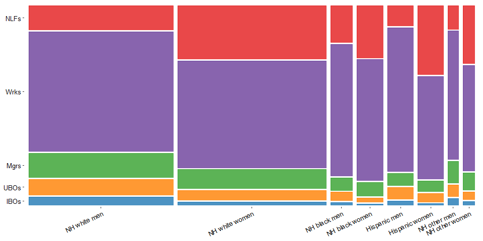

```r
ggplot(data=dat_sub_no_hisp) +
  geom_mosaic(aes(x=product(class, race_h_sex), fill=class, weight=mortwt_f)) +
  ylab("") +
  xlab("")  +
  scale_y_productlist(expand=c(0,0.01)) +
  scale_x_productlist(expand=c(0,0.01)) +
  scale_fill_manual(values=brewer.pal(n = 12, name = "Paired")[c(2,8,4,10,6)]) +
  theme_classic() +
  theme(axis.line=element_blank(), axis.title=element_blank(), legend.position="none",
        axis.text.y=element_text(size=10, color="black"), axis.text.x=element_text(size=10, color="black", angle=25, vjust=1, hjust=1))
```

```r
ggsave('mosaic.png', dpi=600, height=5, width=10)
```

## Proportions in classes over time

Using interview year rather than survey-wave year. Excluded 2019 because <50 respondents interviewed in 2019.

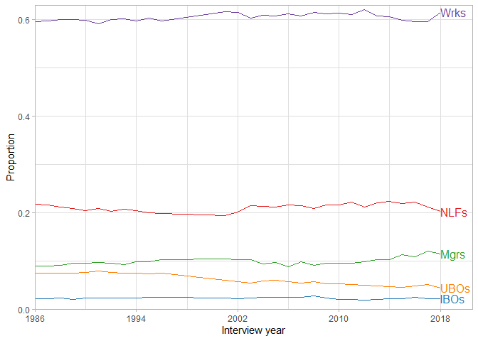

```r
dat_sub_no_hisp %>%
  filter(int_year_fin!=2019) %>%
  group_by(class, int_year_fin) %>%
  summarise(n = sum(mortwt_f)) %>%
  ungroup() %>%
  group_by(int_year_fin) %>%
  mutate(prop = n / sum(n)) -> propped

ggplot(propped, aes(x=int_year_fin, y=prop, group=class, color=class, label=class)) +
  geom_dl(method='last.qp') +
  geom_line() +
  scale_color_manual(values=brewer.pal(n = 12, name = "Paired")[c(2,8,4,10,6)]) +
  scale_x_continuous(breaks=c(1986, 1994, 2002, 2010, 2018), expand=expansion(mult=c(0,0.08))) +
  scale_y_continuous(limits=c(0, 0.63), expand=expansion(mult=c(0,0))) +
  xlab("Interview year") +
  ylab("Proportion") +
  theme_light() +
  theme(legend.position = "none")
```

```r
ggsave('proportions_over_time.png', dpi=600)
```

## Family income distribution across classes from 2007-2018

Income coding inconsistent prior to 2007. Unadjusted for inflation. Row label shows lower bound of category.

```r
x <- svyCreateTableOne(data=subset(dat_sub_no_hisp_svy, year>=2007), vars='incimp1_rev', factorVars='incimp1_rev', strata='class', includeNA=FALSE)
x <- print(x, printToggle=FALSE, noSpaces=TRUE, nonnormal=nonorm, format='p', test=FALSE)
row.names(x)[3:23] <- c(paste0(seq(0,95,5), "k"),">=100k")
kable(x[3:23,]) %>%
  kable_styling(c("striped", "condensed"))
```

|  | IBOs | UBOs | Mgrs | Wrks | NLFs |
| --- | --- | --- | --- | --- | --- |
| 0k | 0.6 | 1.8 | 0.3 | 1.5 | 4.2 |
| 5k | 0.5 | 2.6 | 0.3 | 1.9 | 7.8 |
| 10k | 0.9 | 4.1 | 0.6 | 2.9 | 8.3 |
| 15k | 1.3 | 4.3 | 0.7 | 3.4 | 7.1 |
| 20k | 1.8 | 5.4 | 1.0 | 4.4 | 6.9 |
| 25k | 1.5 | 4.8 | 1.5 | 4.3 | 5.6 |
| 30k | 2.6 | 5.1 | 2.0 | 4.9 | 5.6 |
| 35k | 2.8 | 5.1 | 2.2 | 4.6 | 4.9 |
| 40k | 3.7 | 5.3 | 2.7 | 4.9 | 4.7 |
| 45k | 2.4 | 3.7 | 2.7 | 4.2 | 3.9 |
| 50k | 4.5 | 5.3 | 3.3 | 4.9 | 4.2 |
| 55k | 2.3 | 3.1 | 2.7 | 3.6 | 2.7 |
| 60k | 3.5 | 4.1 | 3.3 | 4.7 | 3.4 |
| 65k | 3.1 | 3.1 | 2.8 | 3.5 | 2.4 |
| 70k | 3.4 | 3.3 | 3.7 | 3.9 | 2.8 |
| 75k | 3.9 | 2.9 | 3.3 | 3.5 | 2.2 |
| 80k | 3.8 | 3.0 | 4.0 | 3.6 | 2.5 |
| 85k | 2.1 | 2.1 | 3.1 | 2.6 | 1.5 |
| 90k | 3.2 | 2.5 | 3.2 | 3.1 | 1.8 |
| 95k | 2.0 | 1.8 | 2.8 | 2.3 | 1.2 |
| >=100k | 50.2 | 26.6 | 53.5 | 27.1 | 16.5 |

## Number of employees at work across classes from 2001-2018

Excluding those not working. IBOs 4x as likely as UBOs to be in firms with 10+ employees. It probably makes sense that managers and workers are much more likely than business owners to work in larger firms, since any given firm, regardless of size, will only have one owner (in theory), whereas such firms will have multiple workers. For example, in a society with 5 firms, 4 of which have 5 employees and 1 of which has 1000 employees, 80% of owners will come from firms with 5 employees, but 98% (1000/1020) of workers will come from firms with 1000+ employees.

```r
x <- svyCreateTableOne(data=subset(dat_sub_no_hisp_svy, year>=2001 & numemps!=0 & class!="NLFs"), vars='numemps', factorVars='numemps', strata='class', includeNA=FALSE)
x <- print(x, printToggle=FALSE, noSpaces=TRUE, nonnormal=nonorm, format='p', test=FALSE)
row.names(x)[3:10] <- c("1-9", "10-24", "25-49", "50-99", "100-249", "250-499", "500-999", "1000+")
kable(x[3:10,1:4]) %>%
  kable_styling(c("striped", "condensed"))
```

|  | IBOs | UBOs | Mgrs | Wrks |
| --- | --- | --- | --- | --- |
| 1-9 | 81.5 | 95.3 | 17.6 | 18.9 |
| 10-24 | 10.3 | 2.6 | 13.7 | 14.9 |
| 25-49 | 4.5 | 0.8 | 11.7 | 12.4 |
| 50-99 | 1.9 | 0.6 | 11.1 | 12.0 |
| 100-249 | 1.2 | 0.3 | 13.2 | 13.9 |
| 250-499 | 0.3 | 0.2 | 8.4 | 7.7 |
| 500-999 | 0.2 | 0.1 | 7.0 | 5.9 |
| 1000+ | 0.2 | 0.2 | 17.4 | 14.4 |

## Reason not in labor force

### Main reason for not working last week

Variable only available from 2004-on.

```r
x <- svyCreateTableOne(data=subset(dat_sub_no_hisp_svy, year>=2004 & empstat==220 & whynowk2!=0), vars='whynowk2', factorVars='whynowk2', includeNA=FALSE)
x <- print(x, printToggle=FALSE, noSpaces=TRUE, nonnormal=nonorm, format='p', test=FALSE)
row.names(x)[3:12] <- c("Keeping house", "Going to school", "Retired", "Unable to work for health reasons", "Disabled", "On layoff", "On planned vacation", "On family leave", "Have job/contract; off season", "Other")
kable(x[3:12,], digits=2, col.names="Percent") %>%
  kable_styling("striped")
```

|  | Percent |
| --- | --- |
| Keeping house | 34.1 |
| Going to school | 4.4 |
| Retired | 17.8 |
| Unable to work for health reasons | 3.2 |
| Disabled | 32.9 |
| On layoff | 2.1 |
| On planned vacation | 0.8 |
| On family leave | 0.4 |
| Have job/contract; off season | 0.8 |
| Other | 3.5 |

### Limited in kind/amount of work can do

Variable only available from 1997-on.

```r
x <- svyCreateTableOne(data=subset(dat_sub_no_hisp_svy, year>=1997), vars='lamtwrk', factorVars='lamtwrk', strata='empstat', includeNA=FALSE)
x <- print(x, printToggle=FALSE, noSpaces=TRUE, nonnormal=nonorm, format='p', test=FALSE)
row.names(x)[3:5] <- c("Not limited", "Limited", "Unable to work")
kable(x[3:5,], col.names=c("Working for pay", "Working w/o pay", "With job, but not at work", "Not employed", "NILF")) %>%
  kable_styling("striped")
```

|  | Working for pay | Working w/o pay | With job, but not at work | Not employed | NILF |
| --- | --- | --- | --- | --- | --- |
| Not limited | 96.9 | 90.8 | 87.9 | 88.0 | 62.9 |
| Limited | 2.6 | 4.9 | 4.6 | 6.1 | 5.9 |
| Unable to work | 0.5 | 4.3 | 7.5 | 5.9 | 31.3 |

# Class and all-cause mortality

```r
#plotting function
plotted <- function(datted,
                    classed_repped=34,
                    classed=c(rep("IBOs", classed_repped), rep("UBOs", classed_repped), rep("Mgrs", classed_repped), rep("Wrks", classed_repped), rep("NLFs", classed_repped)),
                    repped=5,
                    grpd,
                    grps,
                    dummied=c("IBOs", "UBOs", "Mgrs", "Wrks", "NLFs"),
                    cexed=0.85,
                    vjusted=1,
                    val=brewer.pal(n = 12, name = "Paired")[c(2,4,6,8,10)],
                    bottom=0.50){

  dat_surv <- rbind(data.frame(time=datted$time,
                               surved=datted$surv,
                               se=datted$std.err,
                               class=classed,
                               grp=rep(grpd, grps)),
                    data.frame(time=rep(0, repped), surved=rep(1, repped), se=rep(0, repped), class=dummied, grp=rep(grpd, grps)))

  ggplot(dat_surv, aes(x=time, y=surved, group=class, color=class, fill=class, label=class)) +
    facet_wrap(~grp) +
    geom_line() +
    geom_ribbon(aes(ymin=surved-1.96*se, ymax=surved+1.96*se, color=class), alpha=0.2, lty=0) +
    geom_dl(method=list('last.bumpup', cex=cexed, vjust=vjusted)) +
    scale_color_manual(values=val) +
    scale_fill_manual(values=val) +
    xlab("Follow-up time (years)") +
    ylab("Probability of survival") +
    scale_x_continuous(limits=c(0, 34), breaks=seq(1, 34, 3), expand=expansion(mult=c(0,0.11))) +
    scale_y_continuous(limits=c(bottom, 1.0), expand=expansion(mult=c(0,0))) +
    theme_light() +
    theme(legend.position="none", strip.background=element_rect(color="darkgrey", fill=NA),
          strip.text=element_text(color="black"), panel.grid.minor.x = element_blank())
}

#group plotting function
plotted_group <- function(datted,
                    classed_repped=34,
                    classed=rep(c(rep("IBOs", classed_repped), rep("UBOs", classed_repped), rep("Mgrs", classed_repped), rep("Wrks", classed_repped), rep("NLFs", classed_repped)), 2),
                    repped=10,
                    grpd1,
                    grps1=170,
                    grpd2,
                    grps2=170,
                    dummied=c("IBOs", "UBOs", "Mgrs", "Wrks", "NLFs"),
                    levelled=c(grpd1, grpd2),
                    cexed=0.85,
                    vjusted=1,
                    val=brewer.pal(n = 12, name = "Paired")[c(2,4,6,8,10)],
                    bottom=0.50){

  dat_surv <- rbind(data.frame(time=rep(0, repped),
                               surved=rep(1, repped),
                               se=rep(0, repped),
                               class=dummied,
                               grp=c(rep(grpd1, 5), rep(grpd2, 5))),
                    data.frame(time=datted$time,
                               surved=datted$surv,
                               se=datted$std.err,
                               class=classed,
                               grp=c(rep(grpd1, grps1), rep(grpd2, grps2)))) %>%
    mutate(grp=factor(grp, levels=levelled))

  ggplot(dat_surv, aes(x=time, y=surved, group=class, color=class, fill=class, label=class)) +
    facet_wrap(~grp) +
    geom_line() +
    geom_ribbon(aes(ymin=surved-1.96*se, ymax=surved+1.96*se, color=class), alpha=0.2, lty=0) +
    geom_dl(method=list('last.bumpup', cex=cexed, vjust=vjusted)) +
    scale_color_manual(values=val) +
    scale_fill_manual(values=val) +
    xlab("Follow-up time (years)") +
    ylab("Probability of survival") +
    scale_x_continuous(limits=c(0, 34), breaks=seq(1, 34, 3), expand=expansion(mult=c(0,0.11))) +
    scale_y_continuous(limits=c(bottom, 1.0), expand=expansion(mult=c(0,0))) +
    theme_light() +
    theme(legend.position="none", strip.background=element_rect(color="darkgrey", fill=NA),
          strip.text=element_text(color="black"), panel.grid.minor.x = element_blank())
}

#survdiff function
survdiffed <- function(datted,
                       timed=34){

  #end of f/u
  point <- summary(datted, times=timed)

  #pb-cap
  pb <- 100*(point$surv[2] - point$surv[1])
  pb_lower <- 100*(pb/100 - 1.96*sqrt(point$std.err[2]^2 + point$std.err[1]^2))
  pb_upper <- 100*(pb/100 + 1.96*sqrt(point$std.err[2]^2 + point$std.err[1]^2))

  #mc-cap
  mc <- 100*(point$surv[3] - point$surv[1])
  mc_lower <- 100*(mc/100 - 1.96*sqrt(point$std.err[3]^2 + point$std.err[1]^2))
  mc_upper <- 100*(mc/100 + 1.96*sqrt(point$std.err[3]^2 + point$std.err[1]^2))

  #worker-cap
  wc <- 100*(point$surv[4] - point$surv[1])
  wc_lower <- 100*(wc/100 - 1.96*sqrt(point$std.err[4]^2 + point$std.err[1]^2))
  wc_upper <- 100*(wc/100 + 1.96*sqrt(point$std.err[4]^2 + point$std.err[1]^2))

  #nilf-cap
  nc <- 100*(point$surv[5] - point$surv[1])
  nc_lower <- 100*(nc/100 - 1.96*sqrt(point$std.err[5]^2 + point$std.err[1]^2))
  nc_upper <- 100*(nc/100 + 1.96*sqrt(point$std.err[5]^2 + point$std.err[1]^2))

  rbind(c(pb, pb_lower, pb_upper), c(mc, mc_lower, mc_upper), c(wc, wc_lower, wc_upper), c(nc, nc_lower, nc_upper))

}

#survdiff function for worker subdivision
survdiffed_sub <- function(datted,
                           timed=34){

  #end of f/u
  point <- summary(datted, times=timed)

  #pb-cap
  pb <- 100*(point$surv[2] - point$surv[1])
  pb_lower <- 100*(pb/100 - 1.96*sqrt(point$std.err[2]^2 + point$std.err[1]^2))
  pb_upper <- 100*(pb/100 + 1.96*sqrt(point$std.err[2]^2 + point$std.err[1]^2))

  #mc-cap
  mc <- 100*(point$surv[3] - point$surv[1])
  mc_lower <- 100*(mc/100 - 1.96*sqrt(point$std.err[3]^2 + point$std.err[1]^2))
  mc_upper <- 100*(mc/100 + 1.96*sqrt(point$std.err[3]^2 + point$std.err[1]^2))

  #whitecollar-cap
  wc <- 100*(point$surv[4] - point$surv[1])
  wc_lower <- 100*(wc/100 - 1.96*sqrt(point$std.err[4]^2 + point$std.err[1]^2))
  wc_upper <- 100*(wc/100 + 1.96*sqrt(point$std.err[4]^2 + point$std.err[1]^2))

  #services-cap
  servs <- 100*(point$surv[5] - point$surv[1])
  servs_lower <- 100*(servs/100 - 1.96*sqrt(point$std.err[5]^2 + point$std.err[1]^2))
  servs_upper <- 100*(servs/100 + 1.96*sqrt(point$std.err[5]^2 + point$std.err[1]^2))
```

```r
  #bluecollar-cap
  bc <- 100*(point$surv[6] - point$surv[1])
  bc_lower <- 100*(bc/100 - 1.96*sqrt(point$std.err[6]^2 + point$std.err[1]^2))
  bc_upper <- 100*(bc/100 + 1.96*sqrt(point$std.err[6]^2 + point$std.err[1]^2))

  #pb2-cap
  unemp <- 100*(point$surv[7] - point$surv[1])
  unemp_lower <- 100*(unemp/100 - 1.96*sqrt(point$std.err[7]^2 + point$std.err[1]^2))
  unemp_upper <- 100*(unemp/100 + 1.96*sqrt(point$std.err[7]^2 + point$std.err[1]^2))

  #man2-cap
  nilf <- 100*(point$surv[8] - point$surv[1])
  nilf_lower <- 100*(nilf/100 - 1.96*sqrt(point$std.err[8]^2 + point$std.err[1]^2))
  nilf_upper <- 100*(nilf/100 + 1.96*sqrt(point$std.err[8]^2 + point$std.err[1]^2))

  rbind(c(pb, pb_lower, pb_upper), c(mc, mc_lower, mc_upper), c(wc, wc_lower, wc_upper), c(servs, servs_lower, servs_upper),
        c(bc, bc_lower, bc_upper), c(unemp, unemp_lower, unemp_upper), c(nilf, nilf_lower, nilf_upper))

}

#survdiff function for groups
survdiffed_group <- function(datted,
                             timed=34){

  #end of f/u
  point <- summary(datted, times=timed)

  #pb-cap
  pb <- 100*(point$surv[2] - point$surv[1])
  pb_lower <- 100*(pb/100 - 1.96*sqrt(point$std.err[2]^2 + point$std.err[1]^2))
  pb_upper <- 100*(pb/100 + 1.96*sqrt(point$std.err[2]^2 + point$std.err[1]^2))

  #mc-cap
  mc <- 100*(point$surv[3] - point$surv[1])
  mc_lower <- 100*(mc/100 - 1.96*sqrt(point$std.err[3]^2 + point$std.err[1]^2))
  mc_upper <- 100*(mc/100 + 1.96*sqrt(point$std.err[3]^2 + point$std.err[1]^2))

  #worker-cap
  wc <- 100*(point$surv[4] - point$surv[1])
  wc_lower <- 100*(wc/100 - 1.96*sqrt(point$std.err[4]^2 + point$std.err[1]^2))
  wc_upper <- 100*(wc/100 + 1.96*sqrt(point$std.err[4]^2 + point$std.err[1]^2))

  #nilf-cap
  nc <- 100*(point$surv[5] - point$surv[1])
  nc_lower <- 100*(nc/100 - 1.96*sqrt(point$std.err[5]^2 + point$std.err[1]^2))
  nc_upper <- 100*(nc/100 + 1.96*sqrt(point$std.err[5]^2 + point$std.err[1]^2))

  #cap2-cap
  cap2 <- 100*(point$surv[6] - point$surv[1])
  cap2_lower <- 100*(cap2/100 - 1.96*sqrt(point$std.err[6]^2 + point$std.err[1]^2))
  cap2_upper <- 100*(cap2/100 + 1.96*sqrt(point$std.err[6]^2 + point$std.err[1]^2))

  #pb2-cap
  pb2 <- 100*(point$surv[7] - point$surv[1])
  pb2_lower <- 100*(pb2/100 - 1.96*sqrt(point$std.err[7]^2 + point$std.err[1]^2))
  pb2_upper <- 100*(pb2/100 + 1.96*sqrt(point$std.err[7]^2 + point$std.err[1]^2))

  #man2-cap
  man2 <- 100*(point$surv[8] - point$surv[1])
  man2_lower <- 100*(man2/100 - 1.96*sqrt(point$std.err[8]^2 + point$std.err[1]^2))
  man2_upper <- 100*(man2/100 + 1.96*sqrt(point$std.err[8]^2 + point$std.err[1]^2))

  #wrk2-cap
  wrk2 <- 100*(point$surv[9] - point$surv[1])
  wrk2_lower <- 100*(wrk2/100 - 1.96*sqrt(point$std.err[9]^2 + point$std.err[1]^2))
  wrk2_upper <- 100*(wrk2/100 + 1.96*sqrt(point$std.err[9]^2 + point$std.err[1]^2))

  #nilf2-cap
  nilf2 <- 100*(point$surv[10] - point$surv[1])
  nilf2_lower <- 100*(nilf2/100 - 1.96*sqrt(point$std.err[10]^2 + point$std.err[1]^2))
  nilf2_upper <- 100*(nilf2/100 + 1.96*sqrt(point$std.err[10]^2 + point$std.err[1]^2))

  rbind(c(pb, pb_lower, pb_upper), c(mc, mc_lower, mc_upper), c(wc, wc_lower, wc_upper), c(nc, nc_lower, nc_upper),
        c(cap2, cap2_lower, cap2_upper), c(pb2, pb2_lower, pb2_upper), c(man2, man2_lower, man2_upper), c(wrk2, wrk2_lower, wrk2_upper), c(nilf2, nilf2_lower, nilf2_upper))

}

#ests within groups
within_group_ests <- function(datted,
                              timed=34,
                              modded,
                              term1,
                              captioned){

  #######sdiffs
  #end of f/u
  point <- summary(datted, times=timed)

  #pb-cap
  pb <- 100*(point$surv[7] - point$surv[6])
  pb_lower <- 100*(pb/100 - 1.96*sqrt(point$std.err[2]^2 + point$std.err[1]^2))
  pb_upper <- 100*(pb/100 + 1.96*sqrt(point$std.err[2]^2 + point$std.err[1]^2))

  #mc-cap
  mc <- 100*(point$surv[8] - point$surv[6])
  mc_lower <- 100*(mc/100 - 1.96*sqrt(point$std.err[3]^2 + point$std.err[1]^2))
  mc_upper <- 100*(mc/100 + 1.96*sqrt(point$std.err[3]^2 + point$std.err[1]^2))

  #worker-cap
  wc <- 100*(point$surv[9] - point$surv[6])
  wc_lower <- 100*(wc/100 - 1.96*sqrt(point$std.err[4]^2 + point$std.err[1]^2))
  wc_upper <- 100*(wc/100 + 1.96*sqrt(point$std.err[4]^2 + point$std.err[1]^2))

  #nilf-cap
  nc <- 100*(point$surv[10] - point$surv[6])
  nc_lower <- 100*(nc/100 - 1.96*sqrt(point$std.err[5]^2 + point$std.err[1]^2))
  nc_upper <- 100*(nc/100 + 1.96*sqrt(point$std.err[5]^2 + point$std.err[1]^2))

  sdiffs <- rbind(c(pb, pb_lower, pb_upper), c(mc, mc_lower, mc_upper), c(wc, wc_lower, wc_upper), c(nc, nc_lower, nc_upper))

  ######hrs
  hzds <- rbind(exp(confint(glht(modded, linfct=paste0("`", term1, " UBOs` - ", "`", term1, " IBOs", "`", " = 0")))$confint[1:3]),
                exp(confint(glht(modded, linfct=paste0("`", term1, " mgrs` - ", "`", term1, " IBOs", "`", " = 0")))$confint[1:3]),
                exp(confint(glht(modded, linfct=paste0("`", term1, " wrks` - ", "`", term1, " IBOs", "`", " = 0")))$confint[1:3]),
                exp(confint(glht(modded, linfct=paste0("`", term1, " NLFs` - ", "`", term1, " IBOs", "`", " = 0")))$confint[1:3]))

  kable(data.frame(c("classUBOs", "classMgrs", "classWrks", "classNLFs"), hzds, sdiffs), digits=c(2,2,2,2,1,1,1),
        caption=captioned, col.names=c(" ", "HR", "Lower", "Upper", "SD", "Lower", "Upper")) %>%
    kable_styling("striped") %>%
    add_header_above(c(" ", "HR"=3, "SD per 100 at end of f/u"=3))

}

#class-by-year interaction function
int_year_func <- function(modded){

  ests <- data.frame(Class=c("classUBOs", "classUBOs", "classMgrs", "classMgrs", "classWrks", "classWrks", "classNLFs", "classNLFs"),
                     Year=rep(c(1986, 2018),4),
                     HR=exp(c(contrast(modded, list(class='UBOs', int_year_fin=c(1986, 2018)), list(class='IBOs', int_year_fin=c(1986, 2018)))$Contrast,
                              contrast(modded, list(class='Mgrs', int_year_fin=c(1986, 2018)), list(class='IBOs', int_year_fin=c(1986, 2018)))$Contrast,
                              contrast(modded, list(class='Wrks', int_year_fin=c(1986, 2018)), list(class='IBOs', int_year_fin=c(1986, 2018)))$Contrast,
                              contrast(modded, list(class='NLFs', int_year_fin=c(1986, 2018)), list(class='IBOs', int_year_fin=c(1986, 2018)))$Contrast)),
                     Lower=exp(c(contrast(modded, list(class='UBOs', int_year_fin=c(1986, 2018)), list(class='IBOs', int_year_fin=c(1986, 2018)))$Lower,
                                 contrast(modded, list(class='Mgrs', int_year_fin=c(1986, 2018)), list(class='IBOs', int_year_fin=c(1986, 2018)))$Lower,
                                 contrast(modded, list(class='Wrks', int_year_fin=c(1986, 2018)), list(class='IBOs', int_year_fin=c(1986, 2018)))$Lower,
                                 contrast(modded, list(class='NLFs', int_year_fin=c(1986, 2018)), list(class='IBOs', int_year_fin=c(1986, 2018)))$Lower)),
                     Upper=exp(c(contrast(modded, list(class='UBOs', int_year_fin=c(1986, 2018)), list(class='IBOs', int_year_fin=c(1986, 2018)))$Upper,
                                 contrast(modded, list(class='Mgrs', int_year_fin=c(1986, 2018)), list(class='IBOs', int_year_fin=c(1986, 2018)))$Upper,
                                 contrast(modded, list(class='Wrks', int_year_fin=c(1986, 2018)), list(class='IBOs', int_year_fin=c(1986, 2018)))$Upper,
                                 contrast(modded, list(class='NLFs', int_year_fin=c(1986, 2018)), list(class='IBOs', int_year_fin=c(1986, 2018)))$Upper)))
```

```r
  chunked <- anova(modded, int_year_fin)[2,3]

  kable(cbind(ests[c(1,3,5,7),c(1,3:5)], ests[c(2,4,6,8),c(3:5)], data.frame(N=c(length(modded$residuals), rep(NA, 3))), data.frame(P=c(chunked, rep(NA, 3)))),
        row.names=F, digits=c(2,2,2,2,2,2,2,2,20), caption="Ref: IBOs in given year") %>%
    kable_styling("striped") %>%
    add_header_above(c(" ", "1986"=3, "2018"=3, " ", " "))

}

#tidying regression output function
tidy_n <- function(modded,
                   rows=1:4,
                   cols=c(1,2,7,8),
                   bind=binded,
                   nad=3,
                   captioned="Ref: IBOs"){

  tidydf <- cbind(tidy(modded, exponentiate=T, conf.int=T)[rows, cols], bind)
  tidydf$N <- c(length(modded$residuals), rep(NA, nad))
  kable(tidydf, digits=c(2,2,2,2,1,1,1,1), caption=captioned, col.names=c(" ", "HR", "Lower", "Upper", "SD", "Lower", "Upper", "N")) %>%
    kable_styling("striped") %>%
    add_header_above(c(" ", "HR"=3, "SD per 100 at end of f/u"=3, " "))

}
```

## Overall and subdivided by occupation

### Less-adjusted (age, gender, year)

#### Distribution of IPW

##### Overall

```r
dat_sub_no_hisp %>%
  mutate(sw_over=ipwpoint(exposure=class,
                          family="multinomial",
                          link="logit",
                          numerator=~1,
                          denominator=~rcs(age, 3) + sex + rcs(int_year_fin, 5),
                          data=dat_sub_no_hisp,
                          weights=mortwt_f,
                          trace=FALSE,
                          maxit=1000)$ipw.weights,
         sw_f_over=sw_over*mortwt_f)  -> dat_sub_no_hisp

summary(dat_sub_no_hisp$sw_over)
```

```
##    Min. 1st Qu.  Median    Mean 3rd Qu.    Max.
##  0.3329  0.8487  0.9529  0.9900  1.0506  6.2952
```

##### Subdivided

```r
dat_sub_no_hisp %>%
  mutate(sw_sub=ipwpoint(exposure=class_occ,
                         family="multinomial",
                         link="logit",
                         numerator=~1,
                         denominator=~rcs(age, 3) + sex + rcs(int_year_fin, 5),
                         data=dat_sub_no_hisp,
                         weights=mortwt_f,
                         maxit=1000,
                         trace=FALSE)$ipw.weights,
         sw_f_sub=sw_sub*mortwt_f)  -> dat_sub_no_hisp

summary(dat_sub_no_hisp$sw_sub)
```

```
##    Min. 1st Qu.  Median    Mean 3rd Qu.    Max.
##  0.3315  0.7107  0.8659  0.9960  1.1579  7.7834
```

#### Covariate balance after weighting

##### Overall

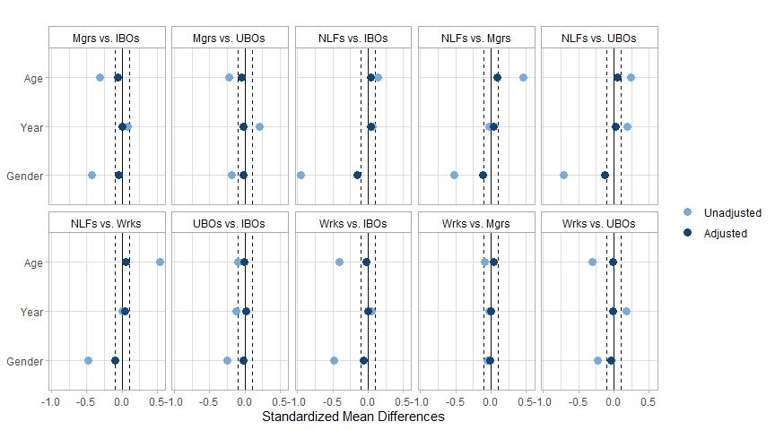

```r
covs <- subset(dat_sub_no_hisp, select=c('age', 'year', 'sex'))

love.plot(covs,
          treat=dat_sub_no_hisp$class,
          weights=dat_sub_no_hisp$sw_over,
          threshold=c(m=0.1),
          binary='std',
          which=.all) +
  facet_wrap(~treat, nrow=2) +
  scale_color_manual(values=c("#77AADD", "#114477")) +
  theme_light() +
  theme(legend.title=element_blank(), plot.title=element_blank(),
        strip.background=element_rect(color="darkgrey", fill=NA), strip.text=element_text(color="black")) +
  scale_y_discrete(labels=rev(c("Age", "Year", "Gender")))
```

##### Subdivided

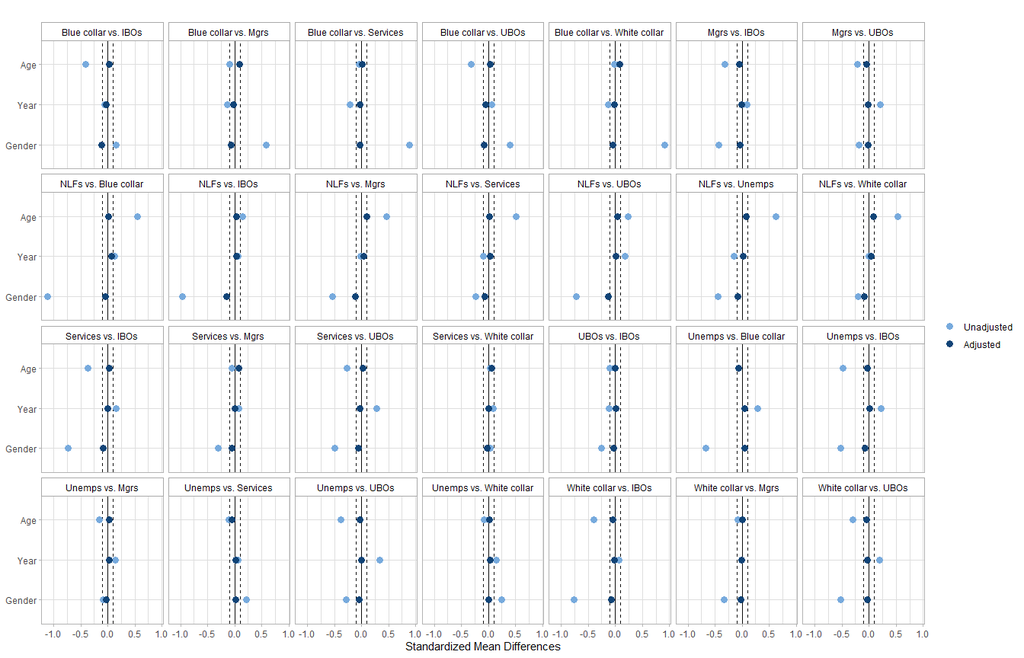

```r
covs <- subset(dat_sub_no_hisp, select=c('age', 'year', 'sex'))

love.plot(covs,
          treat=dat_sub_no_hisp$class_occ,
          weights=dat_sub_no_hisp$sw_sub,
          threshold=c(m=0.1),
          binary='std',
          which=.all) +
  facet_wrap(~treat, nrow=4) +
  scale_color_manual(values=c("#77AADD", "#114477")) +
  theme_light() +
  theme(legend.title=element_blank(), plot.title=element_blank(),
        strip.background=element_rect(color="darkgrey", fill=NA), strip.text=element_text(color="black")) +
  scale_y_discrete(labels=rev(c("Age", "Year", "Gender")))
```

#### Survival

```r
#overall
kapped_over <- survfit(Surv(time,dead)~class, robust=T, w=sw_f_over, data=dat_sub_no_hisp, se=T)
mod_over <- coxph(Surv(time,dead)~class, robust=T, w=sw_f_over, data=dat_sub_no_hisp)
binded_over <- survdiffed(datted=kapped_over)

#subdivided workers
kapped_sub <- survfit(Surv(time,dead)~class_occ, robust=T, w=sw_f_sub, data=dat_sub_no_hisp, se=T)
mod_sub <- coxph(Surv(time,dead)~class_occ, robust=T, w=sw_f_sub, data=dat_sub_no_hisp)
binded_sub <- survdiffed_sub(datted=kapped_sub)
```

##### IPW survival plots

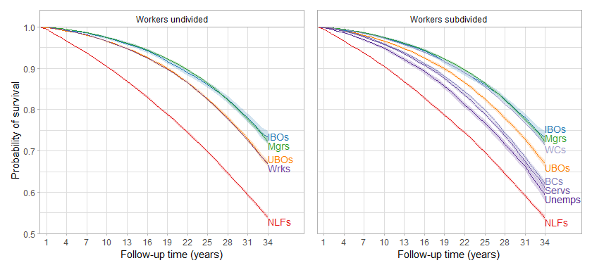

```r
plotted(datted=kapped_over,
        grpd="Workers undivided",
        grps=170) +
  scale_x_continuous(limits=c(0, 34), breaks=seq(1, 34, 3), expand=expansion(mult=c(0,0.16))) +
plotted(datted=kapped_sub,
        classed=factor(c(rep("IBOs", 34), rep("UBOs", 34), rep("Mgrs", 34), rep("WCs", 34), rep("Servs", 34),
                         rep("BCs", 34), rep("Unemps", 34), rep("NLFs", 34)),
                       levels=c("IBOs", "UBOs", "Mgrs", "WCs", "BCs", "Servs", "Unemps", "NLFs")),
        grpd="Workers subdivided",
        grps=272,
        repped=8,
        dummied=c("IBOs", "UBOs", "Mgrs", "WCs", "Servs", "BCs", "Unemps", "NLFs"),
        val=c(brewer.pal(n = 12, name = "Paired")[c(2,8,4)], brewer.pal(n=9, name="Purples")[c(5,6,7,8)], brewer.pal(n = 12, name = "Paired")[c(6)])) +
  scale_x_continuous(limits=c(0, 34), breaks=seq(1, 34, 3), expand=expansion(mult=c(0,0.16))) +
  theme(axis.title.y=element_blank(), axis.text.y=element_blank(), axis.ticks.y=element_blank())
```

```r
ggsave("overall_subdivided.png", dpi=600, height=4, width=8.75)
```

##### IPW survival differences and hazard ratios

```r
tidy_n(modded=mod_over, bind=binded_over)
```

Ref: IBOs

|  | HR | HR Lower | HR Upper | SD per 100 at end of f/u SD | SD per 100 at end of f/u Lower | SD per 100 at end of f/u Upper | N |
| --- | --- | --- | --- | --- | --- | --- | --- |
| classUBOs | 1.28 | 1.21 | 1.36 | -6.3 | -8.1 | -4.6 | 911850 |
| classMgrs | 0.99 | 0.93 | 1.05 | -1.0 | -2.7 | 0.7 |  |
| classWrks | 1.29 | 1.22 | 1.36 | -6.6 | -8.1 | -5.0 |  |
| classNLFs | 2.57 | 2.44 | 2.72 | -19.4 | -21.0 | -17.7 |  |

```r
tidy_n(modded=mod_sub, bind=binded_sub, rows=1:7, nad=6)
```

Ref: IBOs

|  | HR | HR Lower | HR Upper | SD per 100 at end of f/u SD | SD per 100 at end of f/u Lower | SD per 100 at end of f/u Upper | N |
| --- | --- | --- | --- | --- | --- | --- | --- |
| class_occUBOs | 1.28 | 1.21 | 1.36 | -6.4 | -8.1 | -4.6 | 911850 |
| class_occMgrs | 0.99 | 0.93 | 1.05 | -1.0 | -2.8 | 0.7 |  |
| class_occWhite collar | 1.05 | 0.99 | 1.11 | -1.9 | -3.5 | -0.3 |  |
| class_occServices | 1.58 | 1.49 | 1.67 | -12.2 | -14.0 | -10.4 |  |
| class_occBlue collar | 1.51 | 1.43 | 1.60 | -11.2 | -13.0 | -9.5 |  |
| class_occUnemps | 1.77 | 1.66 | 1.88 | -14.0 | -16.1 | -11.9 |  |
| class_occNLFs | 2.58 | 2.45 | 2.73 | -19.6 | -21.2 | -17.9 |  |

### More-adjusted (age, gender, year, education, marital status, region, and racialized group)

#### Distribution of IPW

Truncated at 0.5% and 99.5%.

##### Overall

```r
dat_sub_no_hisp %>%
  mutate(sw_over_adj=ipwpoint(exposure=class,
                              family="multinomial",
                              link="logit",
                              numerator=~1,
                              denominator=~rcs(age, 3) + sex + rcs(int_year_fin, 5) + educ + marital_tri + region + race_h,
                              data=dat_sub_no_hisp,
                              weights=mortwt_f,
                              trace=FALSE,
                              maxit=1000,
                              trunc=0.005)$weights.trunc,
         sw_f_over_adj=sw_over_adj*mortwt_f)  -> dat_sub_no_hisp

summary(dat_sub_no_hisp$sw_over_adj)
```

```
##    Min. 1st Qu.  Median    Mean 3rd Qu.    Max.
##  0.2793  0.7963  0.9183  0.9817  1.0791  3.8188
```

##### Subdivided

```r
dat_sub_no_hisp %>%
  mutate(sw_sub_adj=ipwpoint(exposure=class_occ,
                         family="multinomial",
                         link="logit",
                         numerator=~1,
                         denominator=~rcs(age, 3) + sex + rcs(int_year_fin, 5) + educ + marital_tri + region + race_h,
                         data=dat_sub_no_hisp,
                         weights=mortwt_f,
                         trace=FALSE,
                         maxit=1000,
                         trunc=0.005)$weights.trunc,
         sw_f_sub_adj=sw_sub_adj*mortwt_f)  -> dat_sub_no_hisp

summary(dat_sub_no_hisp$sw_sub_adj)
```

```
##    Min. 1st Qu.  Median    Mean 3rd Qu.    Max.
##  0.2646  0.5132  0.7314  0.9712  1.1228  6.0451
```

#### Covariate balance after weighting

##### Overall

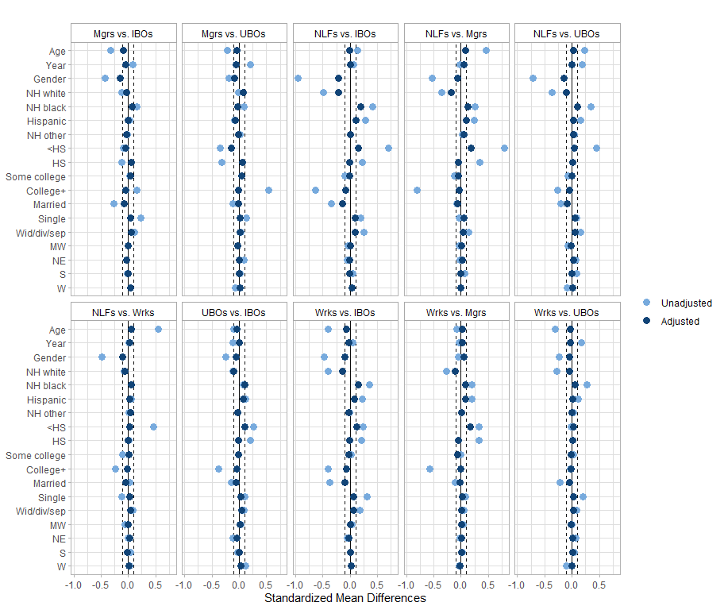

```r
covs <- subset(dat_sub_no_hisp, select=c('age', 'year', 'sex', 'race_h', 'educ', 'marital_tri', 'region'))

love.plot(covs,
          treat=dat_sub_no_hisp$class,
          weights=dat_sub_no_hisp$sw_over_adj,
          threshold=c(m=0.1),
          binary='std',
          which=.all) +
  facet_wrap(~treat, nrow=2) +
  scale_color_manual(values=c("#77AADD", "#114477")) +
  theme_light() +
  theme(legend.title=element_blank(), plot.title=element_blank(),
        strip.background=element_rect(color="darkgrey", fill=NA), strip.text=element_text(color="black")) +
  scale_y_discrete(labels=rev(c("Age", "Year", "Gender", 'NH white', "NH black", "Hispanic", "NH other",
                                "<HS", "HS", "Some college", "College+", "Married", "Single", "Wid/div/sep", "MW", "NE", "S", "W")))
```

##### Subdivided

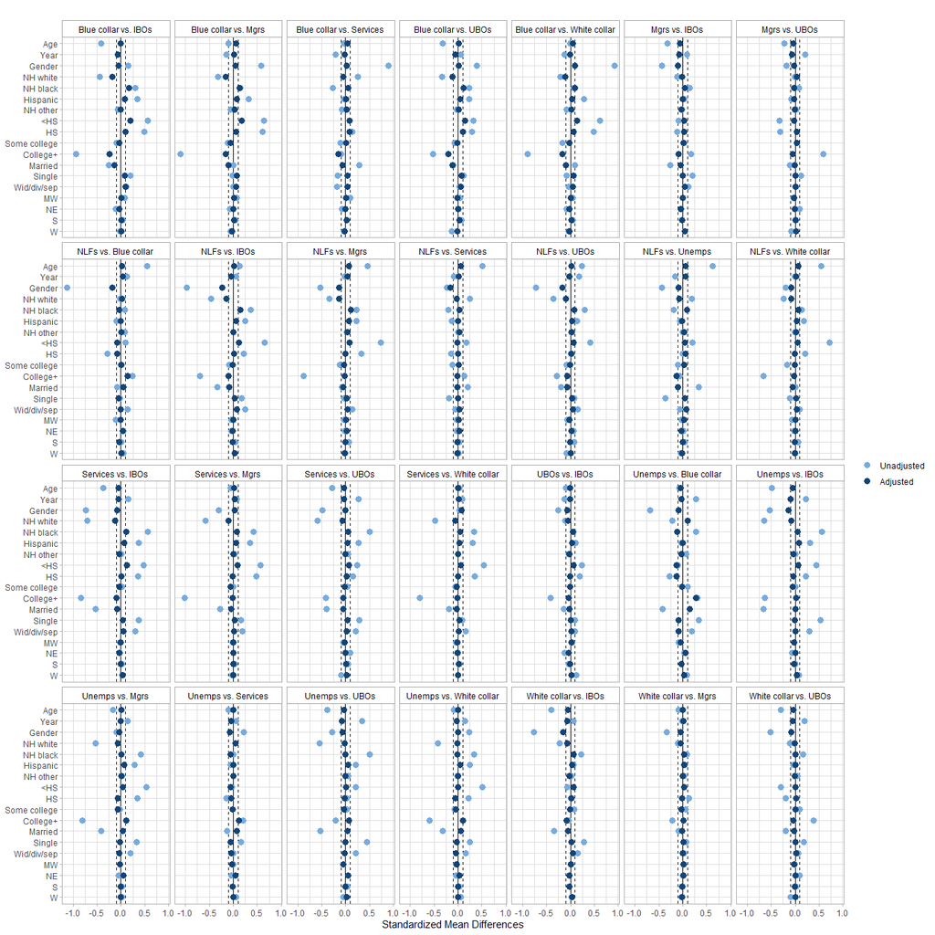

```r
covs <- subset(dat_sub_no_hisp, select=c('age', 'year', 'sex', 'race_h', 'educ', 'marital_tri', 'region'))

love.plot(covs,
          treat=dat_sub_no_hisp$class_occ,
          weights=dat_sub_no_hisp$sw_sub_adj,
          threshold=c(m=0.1),
          binary='std',
          which=.all) +
  facet_wrap(~treat, nrow=4) +
  scale_color_manual(values=c("#77AADD", "#114477")) +
  theme_light() +
  theme(legend.title=element_blank(), plot.title=element_blank(),
        strip.background=element_rect(color="darkgrey", fill=NA), strip.text=element_text(color="black")) +
  scale_y_discrete(labels=rev(c("Age", "Year", "Gender", 'NH white', "NH black", "Hispanic", "NH other",
                                "<HS", "HS", "Some college", "College+", "Married", "Single", "Wid/div/sep", "MW", "NE", "S", "W")))
```

#### Survival

```r
#overall
kapped_over <- survfit(Surv(time,dead)~class, robust=T, w=sw_f_over_adj, data=dat_sub_no_hisp, se=T)
mod_over <- coxph(Surv(time,dead)~class, robust=T, w=sw_f_over_adj, data=dat_sub_no_hisp)
binded_over <- survdiffed(datted=kapped_over)

#subdivided workers
kapped_sub <- survfit(Surv(time,dead)~class_occ, robust=T, w=sw_f_sub_adj, data=dat_sub_no_hisp, se=T)
mod_sub <- coxph(Surv(time,dead)~class_occ, robust=T, w=sw_f_sub_adj, data=dat_sub_no_hisp)
binded_sub <- survdiffed_sub(datted=kapped_sub)
```

##### IPW survival plots

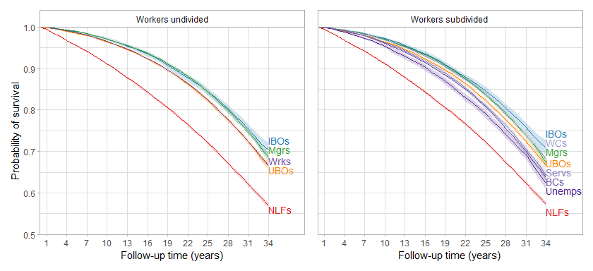

```r
plotted(datted=kapped_over,
        grpd="Workers undivided",
        grps=170) +
  scale_x_continuous(limits=c(0, 34), breaks=seq(1, 34, 3), expand=expansion(mult=c(0,0.16))) +
plotted(datted=kapped_sub,
        classed=factor(c(rep("IBOs", 34), rep("UBOs", 34), rep("Mgrs", 34), rep("WCs", 34), rep("Servs", 34),
                         rep("BCs", 34), rep("Unemps", 34), rep("NLFs", 34)),
                       levels=c("IBOs", "UBOs", "Mgrs", "WCs", "Servs", "BCs", "Unemps", "NLFs")),
        grpd="Workers subdivided",
        grps=272,
        repped=8,
        dummied=c("IBOs", "UBOs", "Mgrs", "WCs", "Servs", "BCs", "Unemps", "NLFs"),
        vjusted=1.5,
        val=c(brewer.pal(n = 12, name = "Paired")[c(2,8,4)], brewer.pal(n=9, name="Purples")[c(5,6,7,8)], brewer.pal(n = 12, name = "Paired")[c(6)])) +
  scale_x_continuous(limits=c(0, 34), breaks=seq(1, 34, 3), expand=expansion(mult=c(0,0.16))) +
  theme(axis.title.y=element_blank(), axis.text.y=element_blank(), axis.ticks.y=element_blank())
```

```r
ggsave("overall_subdivided_adj.png", dpi=600, height=4, width=8.75)
```

##### IPW survival differences and hazard ratios

```r
tidy_n(modded=mod_over, bind=binded_over)
```

Ref: IBOs

|  | HR | HR Lower | HR Upper | SD per 100 at end of f/u SD | SD per 100 at end of f/u Lower | SD per 100 at end of f/u Upper | N |
| --- | --- | --- | --- | --- | --- | --- | --- |
| classUBOs | 1.17 | 1.10 | 1.24 | -3.9 | -5.9 | -1.9 | 911850 |
| classMgrs | 1.02 | 0.95 | 1.08 | -2.0 | -4.1 | 0.1 |  |
| classWrks | 1.15 | 1.09 | 1.22 | -3.8 | -5.6 | -2.0 |  |
| classNLFs | 2.08 | 1.97 | 2.21 | -13.4 | -15.3 | -11.5 |  |

```r
tidy_n(modded=mod_sub, bind=binded_sub, rows=1:7, nad=6)
```

Ref: IBOs

|  | HR | HR Lower | HR Upper | SD per 100 at end of f/u SD | SD per 100 at end of f/u Lower | SD per 100 at end of f/u Upper | N |
| --- | --- | --- | --- | --- | --- | --- | --- |
| class_occUBOs | 1.18 | 1.11 | 1.26 | -4.2 | -6.2 | -2.3 | 911850 |
| class_occMgrs | 1.08 | 1.01 | 1.15 | -3.6 | -5.8 | -1.5 |  |
| class_occWhite collar | 1.09 | 1.02 | 1.16 | -2.8 | -4.6 | -0.9 |  |
| class_occServices | 1.26 | 1.19 | 1.35 | -6.8 | -8.9 | -4.6 |  |
| class_occBlue collar | 1.31 | 1.23 | 1.39 | -7.1 | -9.1 | -5.2 |  |
| class_occUnemps | 1.43 | 1.33 | 1.54 | -8.5 | -10.9 | -6.1 |  |
| class_occNLFs | 2.10 | 1.98 | 2.23 | -13.6 | -15.5 | -11.8 |  |

## Class-by-year stratification - 1986-1996 interview years w/ f/u through end of 2004 vs 2001-2019 interview years w/ f/u through end of 2019

### Less-adjusted

#### Distribution of IPW

##### 1986-1996

```r
dat_sub_no_hisp %>%
  filter(int_year_fin<=1996) %>%
  mutate(sw=ipwpoint(exposure=class,
                     family="multinomial",
                     link="logit",
                     numerator=~1,
                     denominator=~rcs(age, 3) + sex + rcs(int_year_fin, 3),
                     data=subset(dat_sub_no_hisp, int_year_fin<=1996),
                     weights=mortwt_f,
                     maxit=1000,
                     trace=FALSE)$ipw.weights,
         sw_f=sw*mortwt_f)  -> dat_sub_no_hisp_1986

summary(dat_sub_no_hisp_1986$sw)
```

```
##    Min. 1st Qu.  Median    Mean 3rd Qu.    Max.
##  0.2927  0.8250  0.9391  0.9977  1.0344  6.4528
```

##### 2001-2019

```r
dat_sub_no_hisp %>%
  filter(int_year_fin>=2001) %>%
  mutate(sw=ipwpoint(exposure=class,
                     family="multinomial",
                     link="logit",
                     numerator=~1,
                     denominator=~rcs(age, 3) + sex + rcs(int_year_fin, 3),
                     data=subset(dat_sub_no_hisp, int_year_fin>=2001),
                     weights=mortwt_f,
                     maxit=1000,
                     trace=FALSE)$ipw.weights,
         sw_f=sw*mortwt_f)  -> dat_sub_no_hisp_2001

summary(dat_sub_no_hisp_2001$sw)
```

```
##    Min. 1st Qu.  Median    Mean 3rd Qu.    Max.
##  0.3542  0.8552  0.9421  0.9991  1.0757  5.5827
```

#### Survival

```r
#early
kapped_early <- survfit(Surv(time_86_96_05, dead_86_96_05)~class, robust=T, w=sw_f, data=dat_sub_no_hisp_1986, se=T)
mod_early <- coxph(Surv(time_86_96_05, dead_86_96_05)~class, robust=T, w=sw_f, data=dat_sub_no_hisp_1986)
binded_early <- survdiffed(kapped_early, timed=19)

#late
kapped_late <- survfit(Surv(time,dead)~class, robust=T, w=sw_f, data=dat_sub_no_hisp_2001, se=T)
mod_late <- coxph(Surv(time,dead)~class, robust=T, w=sw_f, data=dat_sub_no_hisp_2001)
binded_late <- survdiffed(kapped_late, timed=19)
```

##### IPW survival plots

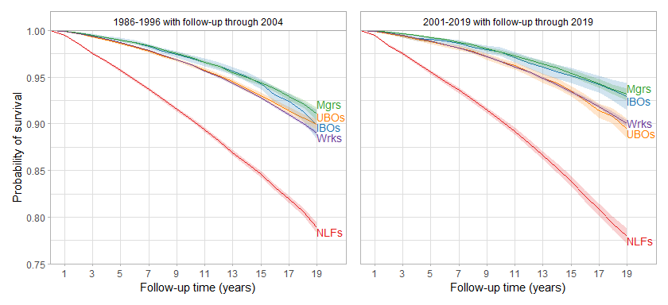

```r
plotted(datted=kapped_early,
        classed_repped=19,
        grpd="1986-1996 with follow-up through 2004",
        grps=95,
        bottom=0.75) +
  scale_x_continuous(limits=c(0, 19), breaks=seq(1, 19, 2), expand=expansion(mult=c(0,0.11)))  +
plotted(datted=kapped_late,
        classed_repped=19,
        grpd="2001-2019 with follow-up through 2019",
        grps=95,
        bottom=0.75) +
  scale_x_continuous(limits=c(0, 19), breaks=seq(1, 19, 2), expand=expansion(mult=c(0,0.11))) +
  theme(axis.title.y=element_blank(), axis.text.y=element_blank(), axis.ticks.y=element_blank())
```

```r
ggsave("change_over_time.png", dpi=600, height=4, width=8.75)
```

##### IPW survival differences and hazard ratios

```r
tidy_n(modded=mod_early, bind=binded_early, captioned="Ref: IBOs (1986-1996 subset)")
```

Ref: IBOs (1986-1996 subset)

|  | HR | HR Lower | HR Upper | SD per 100 at end of f/u SD | SD per 100 at end of f/u Lower | SD per 100 at end of f/u Upper | N |
| --- | --- | --- | --- | --- | --- | --- | --- |
| classUBOs | 1.17 | 1.05 | 1.29 | 0.0 | -1.7 | 1.7 | 564202 |
| classMgrs | 0.95 | 0.86 | 1.06 | 1.2 | -0.6 | 2.9 |  |
| classWrks | 1.22 | 1.10 | 1.34 | -0.9 | -2.5 | 0.7 |  |
| classNLFs | 2.79 | 2.53 | 3.07 | -11.0 | -12.7 | -9.3 |  |

```r
tidy_n(modded=mod_late, bind=binded_late, captioned="Ref: IBOs (2001-2019 subset)")
```

Ref: IBOs (2001-2019 subset)

|  | HR | HR Lower | HR Upper | SD per 100 at end of f/u SD | SD per 100 at end of f/u Lower | SD per 100 at end of f/u Upper | N |
| --- | --- | --- | --- | --- | --- | --- | --- |
| classUBOs | 1.38 | 1.16 | 1.65 | -3.5 | -5.2 | -1.7 | 347648 |
| classMgrs | 0.93 | 0.78 | 1.11 | 0.3 | -1.3 | 1.8 |  |
| classWrks | 1.36 | 1.16 | 1.59 | -2.9 | -4.3 | -1.4 |  |
| classNLFs | 3.80 | 3.24 | 4.45 | -14.9 | -16.6 | -13.3 |  |

### More-adjusted

#### Distribution of IPW

Truncated at 0.5% and 99.5%.

##### 1986-1996

```r
dat_sub_no_hisp %>%
  filter(int_year_fin<=1996) %>%
  mutate(sw=ipwpoint(exposure=class,
                     family="multinomial",
                     link="logit",
                     numerator=~1,
                     denominator=~rcs(age, 3) + sex + rcs(int_year_fin, 3) + educ + marital_tri + region + race_h,
                     data=subset(dat_sub_no_hisp, int_year_fin<=1996),
                     weights=mortwt_f,
                     trace=FALSE,
                     maxit=1000,
                     trunc=0.005)$weights.trunc,
         sw_f=sw*mortwt_f)  -> dat_sub_no_hisp_1986

summary(dat_sub_no_hisp_1986$sw)
```

```
##    Min. 1st Qu.  Median    Mean 3rd Qu.    Max.
##  0.2562  0.7771  0.9153  0.9863  1.0726  4.3989
```

##### 2001-2019

```r
dat_sub_no_hisp %>%
  filter(int_year_fin>=2001) %>%
  mutate(sw=ipwpoint(exposure=class,
                     family="multinomial",
                     link="logit",
                     numerator=~1,
                     denominator=~rcs(age, 3) + sex + rcs(int_year_fin, 3) + educ + marital_tri + region + race_h,
                     data=subset(dat_sub_no_hisp, int_year_fin>=2001),
                     weights=mortwt_f,
                     trace=FALSE,
                     maxit=1000,
                     trunc=0.005)$weights.trunc,
         sw_f=sw*mortwt_f)  -> dat_sub_no_hisp_2001

summary(dat_sub_no_hisp_2001$sw)
```

```
##    Min. 1st Qu.  Median    Mean 3rd Qu.    Max.
##  0.2943  0.8045  0.9188  0.9886  1.0877  3.5681
```

#### Survival

```r
#early
kapped_early <- survfit(Surv(time_86_96_05, dead_86_96_05)~class, robust=T, w=sw_f, data=dat_sub_no_hisp_1986, se=T)
mod_early <- coxph(Surv(time_86_96_05, dead_86_96_05)~class, robust=T, w=sw_f, data=dat_sub_no_hisp_1986)
binded_early <- survdiffed(kapped_early, timed=19)

#late
kapped_late <- survfit(Surv(time,dead)~class, robust=T, w=sw_f, data=dat_sub_no_hisp_2001, se=T)
mod_late <- coxph(Surv(time,dead)~class, robust=T, w=sw_f, data=dat_sub_no_hisp_2001)
binded_late <- survdiffed(kapped_late, timed=19)
```

##### IPW survival plots

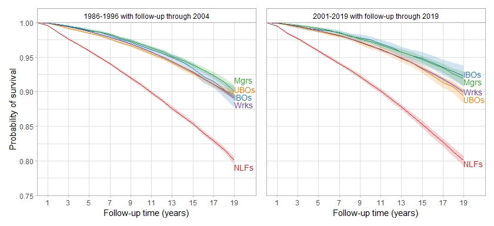

```r
plotted(datted=kapped_early,
        classed_repped=19,
        grpd="1986-1996 with follow-up through 2004",
        grps=95,
        vjusted=1.5,
        bottom=0.75) +
  scale_x_continuous(limits=c(0, 19), breaks=seq(1, 19, 2), expand=expansion(mult=c(0,0.11))) +
plotted(datted=kapped_late,
        classed_repped=19,
        grpd="2001-2019 with follow-up through 2019",
        grps=95,
        bottom=0.75) +
  scale_x_continuous(limits=c(0, 19), breaks=seq(1, 19, 2), expand=expansion(mult=c(0,0.11))) +
  theme(axis.title.y=element_blank(), axis.text.y=element_blank(), axis.ticks.y=element_blank())
```

```r
ggsave("change_over_time_adj.png", dpi=600, height=4, width=8.75)
```

##### IPW survival differences and hazard ratios

```r
tidy_n(modded=mod_early, bind=binded_early, captioned="Ref: IBOs (1986-1996 subset)")
```

Ref: IBOs (1986-1996 subset)

|  | HR | HR Lower | HR Upper | SD per 100 at end of f/u SD | SD per 100 at end of f/u Lower | SD per 100 at end of f/u Upper | N |
| --- | --- | --- | --- | --- | --- | --- | --- |
| classUBOs | 1.09 | 0.98 | 1.21 | 0.3 | -1.3 | 2.0 | 564202 |
| classMgrs | 0.92 | 0.82 | 1.03 | 0.8 | -1.0 | 2.6 |  |
| classWrks | 1.07 | 0.97 | 1.19 | -0.2 | -1.8 | 1.4 |  |
| classNLFs | 2.33 | 2.11 | 2.58 | -9.2 | -10.9 | -7.5 |  |

```r
tidy_n(modded=mod_late, bind=binded_late, captioned="Ref: IBOs (2001-2019 subset)")
```

Ref: IBOs (2001-2019 subset)

|  | HR | HR Lower | HR Upper | SD per 100 at end of f/u SD | SD per 100 at end of f/u Lower | SD per 100 at end of f/u Upper | N |
| --- | --- | --- | --- | --- | --- | --- | --- |
| classUBOs | 1.30 | 1.09 | 1.56 | -2.9 | -4.8 | -1.1 | 347648 |
| classMgrs | 1.01 | 0.84 | 1.22 | -0.3 | -2.1 | 1.5 |  |
| classWrks | 1.25 | 1.06 | 1.47 | -2.3 | -3.8 | -0.7 |  |
| classNLFs | 3.16 | 2.68 | 3.72 | -12.2 | -13.9 | -10.5 |  |

## Class-by-gender and class-by-racialized-group interaction

### Distribution of IPW

#### Gender

```r
dat_sub_no_hisp %>%
  mutate(sw_gend=ipwpoint(exposure=class_gender,
                          family="multinomial",
                          link="logit",
                          numerator=~1,
                          denominator=~rcs(age, 3) + rcs(int_year_fin, 5),
                          data=dat_sub_no_hisp,
                          weights=mortwt_f,
                          maxit=1000,
                          trace=FALSE)$ipw.weights,
         sw_f_gend=sw_gend*mortwt_f,
         gender=ifelse(sex=="female", "Women", "Men"))  -> dat_sub_no_hisp

summary(dat_sub_no_hisp$sw_gend)
```

```
##    Min. 1st Qu.  Median    Mean 3rd Qu.    Max.
##  0.2644  0.8758  0.9455  0.9962  1.0909  4.2343
```

#### Racialized group

```r
dat_sub_no_hisp %>%
  mutate(sw_race=ipwpoint(exposure=class_poc,
                          family="multinomial",
                          link="logit",
                          numerator=~1,
                          denominator=~rcs(age, 3) + rcs(int_year_fin, 5),
                          data=dat_sub_no_hisp,
                          weights=mortwt_f,
                          maxit=1000,
                          trace=FALSE)$ipw.weights,
         sw_f_race=sw_race*mortwt_f)  -> dat_sub_no_hisp

summary(dat_sub_no_hisp$sw_race)
```

```
##    Min. 1st Qu.  Median    Mean 3rd Qu.    Max.
##  0.3181  0.8442  0.9380  1.0063  1.1222  6.1245
```

### Survival

```r
#gender
kapped_gend <- survfit(Surv(time,dead)~class_gender, robust=T, w=sw_f_gend, data=dat_sub_no_hisp, se=T)
mod_gend <- coxph(Surv(time,dead)~class_gender, robust=T, w=sw_f_gend, data=dat_sub_no_hisp)
binded_gend <- survdiffed_group(kapped_gend)

#racialized group
kapped_race <- survfit(Surv(time,dead)~class_poc, robust=T, w=sw_f_race, data=dat_sub_no_hisp, se=T)
mod_race <- coxph(Surv(time,dead)~class_poc, robust=T, w=sw_f_race, data=dat_sub_no_hisp)
binded_race <- survdiffed_group(kapped_race)
```

#### IPW survival plots

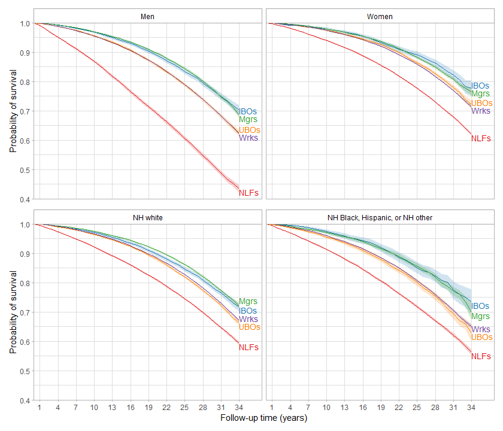

```r
plotted_group(kapped_gend, grpd1="Men", grpd2="Women", bottom=0.40) +
  theme(axis.title.x=element_blank(), axis.text.x=element_blank(), axis.ticks.x=element_blank()) +
plotted_group(kapped_race, grpd1="NH white", grpd2="NH Black, Hispanic, or NH other", bottom=0.40) +
  plot_layout(ncol=1)
```

```r
ggsave("gender_race_survival.png", dpi=600, height=7.5, width=8.75)
```

#### IPW survival differences and hazard ratios

```r
tidy_n(modded=mod_gend, bind=binded_gend, rows=1:9, nad=8, captioned="Ref: male IBOs")
```

Ref: male IBOs

|  | HR | HR Lower | HR Upper | SD per 100 at end of f/u SD | SD per 100 at end of f/u Lower | SD per 100 at end of f/u Upper | N |
| --- | --- | --- | --- | --- | --- | --- | --- |
| class_genderMale UBOs | 1.34 | 1.25 | 1.42 | -7.9 | -9.9 | -5.9 | 911850 |
| class_genderMale mgrs | 0.97 | 0.91 | 1.03 | -1.7 | -3.7 | 0.4 |  |
| class_genderMale wrks | 1.34 | 1.27 | 1.42 | -8.0 | -9.8 | -6.3 |  |
| class_genderMale NLFs | 3.11 | 2.93 | 3.30 | -26.9 | -29.1 | -24.8 |  |
| class_genderFemale IBOs | 0.67 | 0.60 | 0.75 | 7.4 | 4.3 | 10.5 |  |
| class_genderFemale UBOs | 0.84 | 0.78 | 0.90 | 2.0 | -0.2 | 4.2 |  |
| class_genderFemale mgrs | 0.71 | 0.66 | 0.75 | 6.2 | 4.2 | 8.2 |  |
| class_genderFemale wrks | 0.87 | 0.82 | 0.92 | 1.2 | -0.5 | 2.9 |  |
| class_genderFemale NLFs | 1.48 | 1.40 | 1.57 | -8.2 | -10.0 | -6.4 |  |

```r
within_group_ests(datted=kapped_gend, modded=mod_gend, term1="class_genderFemale", captioned="Estimates among women (ref: female IBOs)")
```

Estimates among women (ref: female IBOs)

|  | HR | HR Lower | HR Upper | SD per 100 at end of f/u SD | SD per 100 at end of f/u Lower | SD per 100 at end of f/u Upper |
| --- | --- | --- | --- | --- | --- | --- |
| classUBOs | 1.25 | 1.12 | 1.39 | -5.5 | -7.5 | -3.4 |
| classMgrs | 1.05 | 0.95 | 1.17 | -1.2 | -3.2 | 0.8 |
| classWrks | 1.30 | 1.18 | 1.44 | -6.2 | -8.0 | -4.5 |
| classNLFs | 2.21 | 2.00 | 2.44 | -15.6 | -17.8 | -13.5 |

```r
tidy_n(modded=mod_race, bind=binded_race, rows=1:9, nad=8, captioned="Ref: NH white IBOs")
```

Ref: NH white IBOs

|  | HR | HR Lower | HR Upper | SD per 100 at end of f/u SD | SD per 100 at end of f/u Lower | SD per 100 at end of f/u Upper | N |
| --- | --- | --- | --- | --- | --- | --- | --- |
| class_pocNH white UBOs | 1.21 | 1.14 | 1.28 | -5.3 | -7.2 | -3.5 | 911850 |
| class_pocNH white mgrs | 0.91 | 0.86 | 0.97 | 0.3 | -1.5 | 2.1 |  |
| class_pocNH white wrks | 1.16 | 1.10 | 1.22 | -4.7 | -6.3 | -3.1 |  |
| class_pocNH white NLFs | 1.90 | 1.80 | 2.01 | -12.3 | -14.0 | -10.7 |  |
| class_pocPOC IBOs | 0.91 | 0.80 | 1.05 | 1.6 | -2.9 | 6.2 |  |
| class_pocPOC UBOs | 1.38 | 1.27 | 1.49 | -9.0 | -12.1 | -5.8 |  |
| class_pocPOC mgrs | 0.96 | 0.88 | 1.04 | -1.7 | -5.0 | 1.6 |  |
| class_pocPOC wrks | 1.30 | 1.23 | 1.37 | -6.6 | -8.3 | -4.9 |  |
| class_pocPOC NLFs | 2.13 | 2.01 | 2.25 | -15.5 | -17.3 | -13.6 |  |

```r
within_group_ests(datted=kapped_race, modded=mod_race, term1="class_pocPOC", captioned="Estimates among POC (ref: POC IBOs)")
```

Estimates among POC (ref: POC IBOs)

|  | HR | HR Lower | HR Upper | SD per 100 at end of f/u SD | SD per 100 at end of f/u Lower | SD per 100 at end of f/u Upper |
| --- | --- | --- | --- | --- | --- | --- |
| classUBOs | 1.51 | 1.31 | 1.73 | -10.6 | -12.4 | -8.8 |
| classMgrs | 1.05 | 0.91 | 1.21 | -3.3 | -5.1 | -1.5 |
| classWrks | 1.43 | 1.26 | 1.62 | -8.2 | -9.8 | -6.6 |
| classNLFs | 2.33 | 2.05 | 2.64 | -17.1 | -18.7 | -15.4 |

## Class-by-education interaction

### Distribution of IPW

```r
dat_sub_no_hisp %>%
  mutate(sw_educ=ipwpoint(exposure=class_educ,
                          family="multinomial",
                          link="logit",
                          numerator=~1,
                          denominator=~rcs(age, 3) + rcs(int_year_fin, 5),
                          data=dat_sub_no_hisp,
                          weights=mortwt_f,
                          maxit=1000,
                          trace=FALSE)$ipw.weights,
         sw_f_educ=sw_educ*mortwt_f)  -> dat_sub_no_hisp

summary(dat_sub_no_hisp$sw_educ)
```

```
##    Min. 1st Qu.  Median    Mean 3rd Qu.    Max.
##  0.3094  0.7608  0.9530  0.9949  1.1654  4.2333
```

### Survival

```r
kapped_educ <- survfit(Surv(time,dead)~class_educ, robust=T, w=sw_f_educ, data=dat_sub_no_hisp, se=T)
mod_educ <- coxph(Surv(time,dead)~class_educ, robust=T, w=sw_f_educ, data=dat_sub_no_hisp)
binded_educ <- survdiffed_group(kapped_educ)
```

#### IPW survival plots

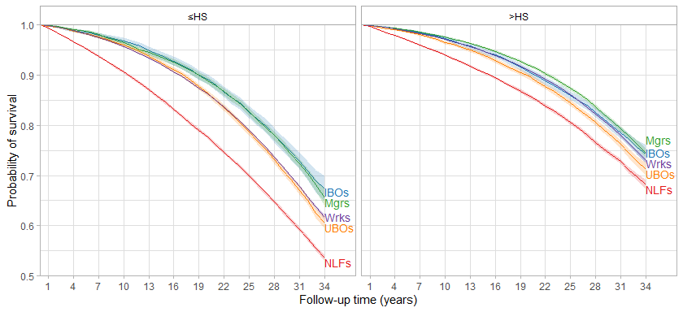

```r
plotted_group(kapped_educ, grpd1=">HS", grpd2="\u2264HS", levelled=c("\u2264HS", ">HS"))
```

```r
ggsave("educ_survival.png", dpi=600, height=4, width=8.75)
```

#### IPW survival differences and hazard ratios

```r
tidy_n(modded=mod_educ, bind=binded_educ, rows=1:9, nad=8, captioned="Ref: >HS IBOs")
```

Ref: >HS IBOs

|  | HR | HR Lower | HR Upper | SD per 100 at end of f/u SD | SD per 100 at end of f/u Lower | SD per 100 at end of f/u Upper | N |
| --- | --- | --- | --- | --- | --- | --- | --- |
| class_educ>HS UBOs | 1.15 | 1.07 | 1.24 | -3.1 | -5.2 | -1.0 | 911850 |
| class_educ>HS mgrs | 0.92 | 0.86 | 0.99 | 0.2 | -1.8 | 2.1 |  |
| class_educ>HS wrks | 1.02 | 0.96 | 1.09 | -1.3 | -3.1 | 0.5 |  |
| class_educ>HS NLFs | 1.54 | 1.44 | 1.65 | -6.1 | -8.1 | -4.2 |  |
| class_educ=HS IBOs | 1.27 | 1.15 | 1.40 | -6.9 | -10.1 | -3.8 |  |
| class_educ=HS UBOs | 1.59 | 1.48 | 1.71 | -13.7 | -15.8 | -11.5 |  |
| class_educ=HS mgrs | 1.30 | 1.20 | 1.41 | -8.7 | -11.1 | -6.3 |  |
| class_educ=HS wrks | 1.59 | 1.49 | 1.69 | -12.6 | -14.4 | -10.8 |  |
| class_educ=HS NLFs | 2.56 | 2.40 | 2.73 | -20.8 | -22.6 | -18.9 |  |

```r
within_group_ests(datted=kapped_educ, modded=mod_educ, term1="class_educ=HS", captioned="Estimates among \u2264HS (ref: \u2264HS IBOs)")
```

Estimates among ≤HS (ref: ≤HS IBOs)

|  | HR | HR Lower | HR Upper | SD per 100 at end of f/u SD | SD per 100 at end of f/u Lower | SD per 100 at end of f/u Upper |
| --- | --- | --- | --- | --- | --- | --- |
| classUBOs | 1.26 | 1.16 | 1.36 | -6.8 | -8.9 | -4.6 |
| classMgrs | 1.03 | 0.94 | 1.12 | -1.8 | -3.8 | 0.2 |
| classWrks | 1.25 | 1.16 | 1.35 | -5.7 | -7.5 | -3.9 |
| classNLFs | 2.02 | 1.87 | 2.18 | -13.8 | -15.8 | -11.9 |

## Class-by-age stratification - 25-44 vs 45-64 years old

### Distribution of IPW

#### 25-44

```r
dat_sub_no_hisp %>%
  filter(age<45) %>%
  mutate(sw=ipwpoint(exposure=class,
                     family="multinomial",
                     link="logit",
                     numerator=~1,
                     denominator=~rcs(age, 3) + sex + rcs(int_year_fin, 5),
                     data=subset(dat_sub_no_hisp, age<45),
                     weights=mortwt_f,
                     maxit=1000,
                     trace=FALSE)$ipw.weights,
         sw_f=sw*mortwt_f)  -> dat_sub_no_hisp_young

summary(dat_sub_no_hisp_young$sw)
```

```
##    Min. 1st Qu.  Median    Mean 3rd Qu.    Max.
##  0.3796  0.8645  0.9763  0.9966  1.1064  7.7873
```

#### 45-64

```r
dat_sub_no_hisp %>%
  filter(age>=45) %>%
  mutate(sw=ipwpoint(exposure=class,
                     family="multinomial",
                     link="logit",
                     numerator=~1,
                     denominator=~rcs(age, 3) + sex + rcs(int_year_fin, 5),
                     data=subset(dat_sub_no_hisp, age>=45),
                     weights=mortwt_f,
                     maxit=1000,
                     trace=FALSE)$ipw.weights,
         sw_f=sw*mortwt_f)  -> dat_sub_no_hisp_old

summary(dat_sub_no_hisp_old$sw)
```

```
##    Min. 1st Qu.  Median    Mean 3rd Qu.    Max.
##  0.3944  0.8366  0.9144  0.9927  1.1012  3.4034
```

### Survival

```r
#young
kapped_young <- survfit(Surv(time,dead)~class, robust=T, w=sw_f, data=dat_sub_no_hisp_young, se=T)
mod_young <- coxph(Surv(time,dead)~class, robust=T, w=sw_f, data=dat_sub_no_hisp_young)
binded_young <- survdiffed(kapped_young)

#old
kapped_old <- survfit(Surv(time,dead)~class, robust=T, w=sw_f, data=dat_sub_no_hisp_old, se=T)
mod_old <- coxph(Surv(time,dead)~class, robust=T, w=sw_f, data=dat_sub_no_hisp_old)
binded_old <- survdiffed(kapped_old)
```

#### IPW survival plots

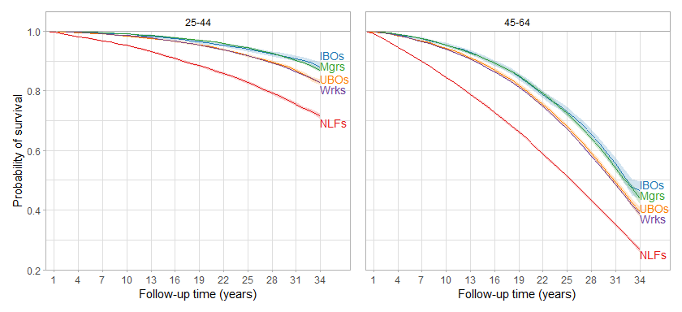

```r
plotted(datted=kapped_young, grpd="25-44", vjust=1.25, bottom=0.2) +
plotted(datted=kapped_old, grpd="45-64", bottom=0.2) +
  theme(axis.title.y=element_blank(), axis.text.y=element_blank(), axis.ticks.y=element_blank())
```

```r
ggsave("age_survival.png", dpi=600, height=4, width=8.75)
```

#### IPW survival differences and hazard ratios

```r
tidy_n(modded=mod_young, bind=binded_young, captioned="Ref: IBOs (25-44 subset)")
```

Ref: IBOs (25-44 subset)

|  | HR | HR Lower | HR Upper | SD per 100 at end of f/u SD | SD per 100 at end of f/u Lower | SD per 100 at end of f/u Upper | N |
| --- | --- | --- | --- | --- | --- | --- | --- |
| classUBOs | 1.42 | 1.25 | 1.62 | -5.2 | -7.0 | -3.3 | 528703 |
| classMgrs | 0.98 | 0.87 | 1.12 | -1.0 | -2.8 | 0.7 |  |
| classWrks | 1.43 | 1.27 | 1.62 | -5.2 | -6.7 | -3.6 |  |
| classNLFs | 3.22 | 2.84 | 3.64 | -16.5 | -18.3 | -14.7 |  |

```r
tidy_n(modded=mod_old, bind=binded_old, captioned="Ref: IBOs (45-64 subset)")
```

Ref: IBOs (45-64 subset)

|  | HR | HR Lower | HR Upper | SD per 100 at end of f/u SD | SD per 100 at end of f/u Lower | SD per 100 at end of f/u Upper | N |
| --- | --- | --- | --- | --- | --- | --- | --- |
| classUBOs | 1.22 | 1.15 | 1.30 | -7.3 | -10.7 | -3.9 | 383147 |
| classMgrs | 1.03 | 0.96 | 1.09 | -2.9 | -6.4 | 0.5 |  |
| classWrks | 1.27 | 1.20 | 1.34 | -8.1 | -11.1 | -5.1 |  |
| classNLFs | 2.38 | 2.25 | 2.52 | -20.1 | -23.1 | -17.0 |  |

## Sensitivity analyses

### Regression adjustment instead of IPW for minimally-adjusted overall Cox analyses

Similar to primary but slightly larger effect sizes for workers and UBOs.

```r
mod_reg <- coxph(Surv(time,dead)~class + rcs(age, 3) + sex + rcs(int_year_fin, 5), robust=T, w=mortwt_f, data=dat_sub_no_hisp)

kable(cbind(tidy(mod_reg, exponentiate=T, conf.int=T)[1:4, c(1,2,7,8)], c(length(mod_reg$residuals), NA, NA, NA)),
      col.names=c(" ", "HR", "Lower", "Upper", "N"), caption="Ref: IBOs", digits=2) %>%
  kable_styling("striped")
```

Ref: IBOs

|  | HR | Lower | Upper | N |
| --- | --- | --- | --- | --- |
| classUBOs | 1.31 | 1.25 | 1.38 | 911850 |
| classMgrs | 1.00 | 0.95 | 1.05 |  |
| classWrks | 1.36 | 1.30 | 1.42 |  |
| classNLFs | 2.49 | 2.38 | 2.61 |  |

### Checking that SEs in primary analyses align with SEs from other approaches

#### Accounting for survey design in overall Cox analyses (adjusting for confounders with IPW)

Basically identical to primary. It makes no difference that we subsetted the dataset by age above rather than within the svycoxph function because age subpopulations appear in all the clusters

```r
dat_sub_no_hisp_svy <- svydesign(ids = ~ psu,
                                 strata = ~ strata,
                                 weights = ~ sw_f_over,
                                 nest=TRUE,
                                 data=dat_sub_no_hisp)

mod_surv <- svycoxph(Surv(time,dead)~class, design=dat_sub_no_hisp_svy)

kable(cbind(tidy(mod_surv, exponentiate=T, conf.int=T)[1:4, c(1,2,7,8)], c(length(mod_surv$residuals), NA, NA, NA)),
      col.names=c(" ", "HR", "Lower", "Upper", "N"), caption="Ref: IBOs", digits=2) %>%
  kable_styling("striped")
```

```
## Stratified 1 - level Cluster Sampling design (with replacement)
## With (2575) clusters.
## svydesign(ids = ~psu, strata = ~strata, weights = ~sw_f_over,
##     nest = TRUE, data = dat_sub_no_hisp)
```

Ref: IBOs

|  | HR | Lower | Upper | N |
| --- | --- | --- | --- | --- |
| classUBOs | 1.28 | 1.20 | 1.36 | 911850 |
| classMgrs | 0.99 | 0.93 | 1.05 |  |
| classWrks | 1.29 | 1.22 | 1.36 |  |
| classNLFs | 2.57 | 2.43 | 2.72 |  |

#### Clustering SEs at household level rather than leaving them unclustered

Also basically identical to primary.

```r
kapped_house <- survfit(Surv(time,dead)~class + cluster(nhishid), w=sw_f_over, data=dat_sub_no_hisp, se=T)
mod_house <- coxph(Surv(time,dead)~class + cluster(nhishid), w=sw_f_over, data=dat_sub_no_hisp)
binded_house <- survdiffed(kapped_house)
```

```r
tidy_n(modded=mod_house, bind=binded_house)
```

Ref: IBOs

|  | HR | HR Lower | HR Upper | SD per 100 at end of f/u SD | SD per 100 at end of f/u Lower | SD per 100 at end of f/u Upper | N |
| --- | --- | --- | --- | --- | --- | --- | --- |
| classUBOs | 1.28 | 1.21 | 1.36 | -6.3 | -8.1 | -4.5 | 911850 |
| classMgrs | 0.99 | 0.93 | 1.05 | -1.0 | -2.8 | 0.7 |  |
| classWrks | 1.29 | 1.22 | 1.36 | -6.6 | -8.2 | -5.0 |  |
| classNLFs | 2.57 | 2.44 | 2.72 | -19.4 | -21.0 | -17.7 |  |

### Including Hispanic oversample to examine effects on point estimates

#### Distribution of IPW

```r
dat_sub %>%
  filter(!is.na(class) & !is.na(age)) %>%
  mutate(sw_hisp=ipwpoint(exposure=class,
                          family="multinomial",
                          link="logit",
                          numerator=~1,
                          denominator=~rcs(age, 3) + sex + rcs(int_year_fin, 5),
                          data=subset(dat_sub, !is.na(class) & !is.na(age)),
                          weights=mortwt_f,
                          maxit=1000,
                          trace=FALSE)$ipw.weights,
         sw_f_hisp=sw_hisp*mortwt_f)  -> dat_sub_hisp_overall

summary(dat_sub_hisp_overall$sw_hisp)
```

```
##    Min. 1st Qu.  Median    Mean 3rd Qu.    Max.
##  0.3347  0.8489  0.9532  0.9901  1.0506  6.2242
```

```r
kapped_hisp <- survfit(Surv(time,dead)~class, robust=T, w=sw_hisp, data=dat_sub_hisp_overall, se=T)
mod_hisp <- coxph(Surv(time,dead)~class, robust=T, w=sw_hisp, data=dat_sub_hisp_overall)
binded_hisp <- survdiffed(kapped_hisp)
```

#### IPW survival differences and hazard ratios

```r
tidy_n(modded=mod_hisp, bind=binded_hisp)
```

Ref: IBOs

|  | HR | HR Lower | HR Upper | SD per 100 at end of f/u SD | SD per 100 at end of f/u Lower | SD per 100 at end of f/u Upper | N |
| --- | --- | --- | --- | --- | --- | --- | --- |
| classUBOs | 1.26 | 1.20 | 1.31 | -6.1 | -7.8 | -4.4 | 925046 |
| classMgrs | 1.00 | 0.96 | 1.05 | -0.9 | -2.6 | 0.7 |  |
| classWrks | 1.29 | 1.24 | 1.35 | -6.8 | -8.2 | -5.3 |  |
| classNLFs | 2.30 | 2.20 | 2.40 | -18.9 | -20.5 | -17.4 |  |

### Excluding NHIS sampling weights from analyses

Similar to primary analyses, but somewhat attenuated.

#### Distribution of IPW

```r
dat_sub_no_hisp %>%
  mutate(sw_over_excl=ipwpoint(exposure=class,
                               family="multinomial",
                               link="logit",
                               numerator=~1,
                               denominator=~rcs(age, 3) + sex + rcs(int_year_fin, 5),
                               data=dat_sub_no_hisp,
                               trace=FALSE,
                               maxit=1000)$ipw.weights)  -> dat_sub_no_hisp

summary(dat_sub_no_hisp$sw_over_excl)
```

```
##    Min. 1st Qu.  Median    Mean 3rd Qu.    Max.
##  0.3267  0.8390  0.9430  0.9967  1.0498  6.6870
```

```r
kapped_over_excl <- survfit(Surv(time,dead)~class, robust=T, w=sw_over_excl, data=dat_sub_no_hisp, se=T)
mod_over_excl <- coxph(Surv(time,dead)~class, robust=T, w=sw_over_excl, data=dat_sub_no_hisp)
binded_over_excl <- survdiffed(datted=kapped_over_excl)
```

#### IPW survival differences and hazard ratios

```r
tidy_n(modded=mod_over_excl, bind=binded_over_excl)
```

Ref: IBOs

|  | HR | HR Lower | HR Upper | SD per 100 at end of f/u SD | SD per 100 at end of f/u Lower | SD per 100 at end of f/u Upper | N |
| --- | --- | --- | --- | --- | --- | --- | --- |
| classUBOs | 1.23 | 1.17 | 1.29 | -5.6 | -7.3 | -3.8 | 911850 |
| classMgrs | 1.01 | 0.97 | 1.06 | -1.1 | -2.8 | 0.6 |  |
| classWrks | 1.28 | 1.23 | 1.34 | -6.5 | -8.1 | -5.0 |  |
| classNLFs | 2.27 | 2.17 | 2.38 | -18.6 | -20.2 | -17.0 |  |

### Class by year interaction with regression adjustment instead of period stratification and IPW

Similar to primary, but imprecise, especially in spline analyses. Used 2018 instead of 2019 as end-of-follow-up year because <50 respondents were interviewed in 2019. Pointwise confidence intervals. P-value is for chunk test of joint significance of interaction term.

#### Year as linear term

##### Less-adjusted

```r
ddist <- datadist(dat_sub_no_hisp)
options(datadist="ddist")
mod_linear <- cph(Surv(time,dead)~class*int_year_fin + rcs(age, 3) + sex + cluster(nhispid), w=mortwt_f, data=dat_sub_no_hisp, x=T, y=T)

int_year_func(modded=mod_linear)
```

Ref: IBOs in given year

| Class | 1986 HR | 1986 Lower | 1986 Upper | 2018 HR | 2018 Lower | 2018 Upper | N | P |
| --- | --- | --- | --- | --- | --- | --- | --- | --- |
| classUBOs | 1.25 | 1.18 | 1.33 | 1.45 | 1.14 | 1.84 | 911850 | 0 |
| classMgrs | 1.04 | 0.98 | 1.11 | 0.89 | 0.70 | 1.14 |  |  |
| classWrks | 1.30 | 1.23 | 1.38 | 1.53 | 1.24 | 1.89 |  |  |
| classNLFs | 1.92 | 1.81 | 2.03 | 4.58 | 3.70 | 5.66 |  |  |

##### More-adjusted

```r
mod_linear_adj <- cph(Surv(time,dead)~class*int_year_fin + rcs(age, 3) + sex + educ + marital_tri + region + race_h + cluster(nhispid), w=mortwt_f, data=dat_sub_no_hisp, x=T, y=T)

int_year_func(modded=mod_linear_adj)
```

Ref: IBOs in given year

| Class | 1986 HR | 1986 Lower | 1986 Upper | 2018 HR | 2018 Lower | 2018 Upper | N | P |
| --- | --- | --- | --- | --- | --- | --- | --- | --- |
| classUBOs | 1.09 | 1.03 | 1.16 | 1.27 | 1.00 | 1.62 | 911850 | 0 |
| classMgrs | 1.04 | 0.98 | 1.11 | 0.92 | 0.73 | 1.17 |  |  |
| classWrks | 1.09 | 1.03 | 1.15 | 1.31 | 1.06 | 1.62 |  |  |
| classNLFs | 1.50 | 1.41 | 1.59 | 3.58 | 2.90 | 4.43 |  |  |

#### Year as 5-knot restricted cubic spline

##### Less-adjusted

```r
mod_spline <- cph(Surv(time,dead)~class*rcs(int_year_fin, 5) + rcs(age, 3) + sex + cluster(nhispid), w=mortwt_f, data=dat_sub_no_hisp, x=T, y=T)

int_year_func(modded=mod_spline)
```

Ref: IBOs in given year

| Class | 1986 HR | 1986 Lower | 1986 Upper | 2018 HR | 2018 Lower | 2018 Upper | N | P |
| --- | --- | --- | --- | --- | --- | --- | --- | --- |
| classUBOs | 1.22 | 1.10 | 1.35 | 1.55 | 0.79 | 3.02 | 911850 | 0 |
| classMgrs | 1.00 | 0.90 | 1.11 | 0.99 | 0.52 | 1.88 |  |  |
| classWrks | 1.21 | 1.10 | 1.32 | 1.55 | 0.88 | 2.74 |  |  |
| classNLFs | 1.90 | 1.73 | 2.09 | 5.64 | 3.20 | 9.93 |  |  |

##### More-adjusted

```r
mod_spline_adj <- cph(Surv(time,dead)~class*rcs(int_year_fin, 5) + rcs(age, 3) + sex + educ + marital_tri + region + race_h + cluster(nhispid), w=mortwt_f, data=dat_sub_no_hisp, x=T, y=T)

int_year_func(modded=mod_spline_adj)
```

Ref: IBOs in given year

| Class | 1986 HR | 1986 Lower | 1986 Upper | 2018 HR | 2018 Lower | 2018 Upper | N | P |
| --- | --- | --- | --- | --- | --- | --- | --- | --- |
| classUBOs | 1.05 | 0.95 | 1.17 | 1.33 | 0.68 | 2.59 | 911850 | 0 |
| classMgrs | 1.00 | 0.90 | 1.11 | 1.04 | 0.55 | 1.98 |  |  |
| classWrks | 1.01 | 0.92 | 1.10 | 1.34 | 0.76 | 2.37 |  |  |
| classNLFs | 1.50 | 1.36 | 1.65 | 4.24 | 2.41 | 7.47 |  |  |

### Including employed “chief executives, general and operative managers, and legislators” in IBO class rather than managerial class from 2005-2018

HR similar to 2001-2019 analysis above. IBO class increases from 5282 to 7650 with change (2368 respondents move from managerial class to IBO class).

```r
dat_sub_no_hisp %>%
  filter(year>=2005) %>%
  mutate(ceo=ifelse(occ==1, 1, 0),
         class_ceo=factor(ifelse(empstat==220, "NLFs",
                                ifelse((empstat>=200 & empstat<=214) | (classwk2>=1 & classwk2<=4 & managers!=1  & ceo!=1), "Workers",
                                      ifelse(classwk2>=1 & classwk2<=4 & managers==1 & ceo!=1, "Managers",
                                            ifelse((classwk2==5 & jobsecincorp==2) | (classwk2>=1 & classwk2<=4 & managers==1 & ceo==1), "IBOs",
                                                    ifelse((classwk2==6  & ceo!=1) | (classwk2==5 & jobsecincorp==1 & ceo!=1), "UBOs", NA))))),
                          levels=c("IBOs", "UBOs", "Managers", "Workers", "NLFs"))) -> dat_sub_no_hisp_2005_ceo

dat_sub_no_hisp_2005_ceo %>%
  filter(!is.na(class_ceo)) %>% #small amount of missingness because using alternative occupation variable
  mutate(sw_ceo=ipwpoint(exposure=class_ceo,
                         family="multinomial",
                         link="logit",
                         numerator=~1,
                         denominator=~rcs(age, 3) + sex + rcs(int_year_fin, 3),
                         data=subset(dat_sub_no_hisp_2005_ceo, !is.na(class_ceo)),
                         weights=mortwt_f,
                         maxit=1000,
                         trace=FALSE)$ipw.weights,
         sw_f_ceo=sw_ceo*mortwt_f)  -> dat_sub_no_hisp_2005_ceo

summary(dat_sub_no_hisp_2005_ceo$sw_ceo)
```

```
##    Min. 1st Qu.  Median    Mean 3rd Qu.    Max.
##  0.3658  0.8542  0.9402  0.9994  1.0789  5.4310
```

```r
kapped_ceo <- survfit(Surv(time,dead)~class, robust=T, w=sw_f_ceo, data=dat_sub_no_hisp_2005_ceo, se=T)
mod_ceo <- coxph(Surv(time,dead)~class, robust=T, w=sw_f_ceo, data=dat_sub_no_hisp_2005_ceo)
binded_ceo <- survdiffed(kapped_ceo, timed=15)
```

#### IPW survival differences and hazard ratios

```r
tidy_n(modded=mod_ceo, bind=binded_ceo)
```

Ref: IBOs

|  | HR | HR Lower | HR Upper | SD per 100 at end of f/u SD | SD per 100 at end of f/u Lower | SD per 100 at end of f/u Upper | N |
| --- | --- | --- | --- | --- | --- | --- | --- |
| classUBOs | 1.28 | 1.00 | 1.64 | -1.2 | -2.8 | 0.4 | 266803 |
| classMgrs | 0.89 | 0.70 | 1.14 | 0.6 | -0.9 | 2.0 |  |
| classWrks | 1.32 | 1.06 | 1.65 | -1.5 | -2.9 | -0.2 |  |
| classNLFs | 4.01 | 3.21 | 5.01 | -11.4 | -13.0 | -9.8 |  |

# Confirming class variables are coded correctly

```r
kable(table(dat_sub_no_hisp$class, dat_sub_no_hisp$empstat), caption="Confirming that all unemployed (200-214) are workers and all NLF (220) are NLF") %>%
  kable_styling("striped")
```

Confirming that all unemployed (200-214) are workers and all NLF (220) are NLF

|  | 110 | 111 | 112 | 120 | 121 | 122 | 200 | 211 | 212 | 213 | 214 | 220 |
| --- | --- | --- | --- | --- | --- | --- | --- | --- | --- | --- | --- | --- |
| IBOs | 12350 | 6237 | 417 | 248 | 180 | 5 | 0 | 0 | 0 | 0 | 0 | 0 |
| UBOs | 41068 | 15440 | 1716 | 803 | 1010 | 58 | 0 | 0 | 0 | 0 | 0 | 0 |
| Mgrs | 51167 | 32370 | 93 | 1041 | 601 | 21 | 0 | 0 | 0 | 0 | 0 | 0 |
| Wrks | 311123 | 186940 | 567 | 8041 | 6261 | 214 | 16083 | 1232 | 95 | 3493 | 13789 | 0 |
| NLFs | 0 | 0 | 0 | 0 | 0 | 0 | 0 | 0 | 0 | 0 | 0 | 199187 |

```r
kable(table(dat_sub_no_hisp$class, dat_sub_no_hisp$managers), caption="Class by manager: 1=managers") %>%
  kable_styling("striped")
```

Class by manager: 1=managers

|  | 0 | 1 |
| --- | --- | --- |
| IBOs | 12319 | 7028 |
| UBOs | 49415 | 10246 |
| Mgrs | 0 | 85293 |
| Wrks | 543859 | 2710 |
| NLFs | 193453 | 4596 |

```r
kable(table(subset(dat_sub_no_hisp, managers==1)$class, subset(dat_sub_no_hisp, managers==1)$empstat), caption="Confirming that all workers and NLFs who have 'managers==1' are either unemp or NLF") %>%
  kable_styling("striped")
```

Confirming that all workers and NLFs who have ‘managers==1’ are either unemp or NLF

|  | 110 | 111 | 112 | 120 | 121 | 122 | 200 | 211 | 212 | 213 | 214 | 220 |
| --- | --- | --- | --- | --- | --- | --- | --- | --- | --- | --- | --- | --- |
| IBOs | 4806 | 1923 | 140 | 86 | 73 | 0 | 0 | 0 | 0 | 0 | 0 | 0 |
| UBOs | 7293 | 2212 | 440 | 122 | 170 | 9 | 0 | 0 | 0 | 0 | 0 | 0 |
| Mgrs | 51167 | 32370 | 93 | 1041 | 601 | 21 | 0 | 0 | 0 | 0 | 0 | 0 |
| Wrks | 0 | 0 | 0 | 0 | 0 | 0 | 1259 | 50 | 11 | 363 | 1027 | 0 |
| NLFs | 0 | 0 | 0 | 0 | 0 | 0 | 0 | 0 | 0 | 0 | 0 | 4596 |

```r
kable(table(subset(dat_sub_no_hisp, managers==1 & year<2001)$class, subset(dat_sub_no_hisp, managers==1 & year<2001)$classwk),
      caption="1986-1996: confirming that all IBOs and UBOs who have 'managers==1' are self-employed") %>%
  kable_styling("striped")
```

1986-1996: confirming that all IBOs and UBOs who have ‘managers==1’ are self-employed

|  | 20 | 31 | 33 | 34 | 41 | 42 | 50 |
| --- | --- | --- | --- | --- | --- | --- | --- |
| IBOs | 0 | 0 | 0 | 0 | 4879 | 0 | 0 |
| UBOs | 0 | 0 | 0 | 0 | 0 | 7392 | 80 |
| Mgrs | 41858 | 2881 | 3089 | 3961 | 0 | 0 | 0 |
| Wrks | 1079 | 52 | 43 | 66 | 66 | 137 | 4 |
| NLFs | 0 | 0 | 0 | 0 | 0 | 0 | 0 |

```r
kable(table(subset(dat_sub_no_hisp, managers==1 & year>=2001)$class, subset(dat_sub_no_hisp, managers==1 & year>=2001)$classwk2),
      caption="2001-2018: confirming that all IBOs and UBOs who have 'managers==1' are self-employed") %>%
  kable_styling("striped")
```

2001-2018: confirming that all IBOs and UBOs who have ‘managers==1’ are self-employed

|  | 1 | 2 | 3 | 4 | 5 | 6 |
| --- | --- | --- | --- | --- | --- | --- |
| IBOs | 0 | 0 | 0 | 0 | 2149 | 0 |
| UBOs | 0 | 0 | 0 | 0 | 2663 | 111 |
| Mgrs | 28195 | 1486 | 2057 | 1766 | 0 | 0 |
| Wrks | 1069 | 31 | 33 | 23 | 95 | 3 |
| NLFs | 3199 | 318 | 339 | 262 | 457 | 10 |

```r
kable(table(subset(dat_sub_no_hisp, year<2001)$class, subset(dat_sub_no_hisp, year<2001)$classwk), caption="1986-1996: class by classwk; all 41 are IBO/wrk and 42-50 are UBO/wrk") %>%
  kable_styling("striped")
```

1986-1996: class by classwk; all 41 are IBO/wrk and 42-50 are UBO/wrk

|  | 11 | 12 | 20 | 31 | 33 | 34 | 41 | 42 | 50 |
| --- | --- | --- | --- | --- | --- | --- | --- | --- | --- |
| IBOs | 0 | 0 | 0 | 0 | 0 | 0 | 12535 | 0 | 0 |
| UBOs | 0 | 0 | 0 | 0 | 0 | 0 | 0 | 41362 | 774 |
| Mgrs | 0 | 0 | 41858 | 2881 | 3089 | 3961 | 0 | 0 | 0 |
| Wrks | 0 | 216 | 270685 | 11440 | 16426 | 35591 | 147 | 917 | 23 |
| NLFs | 121535 | 0 | 0 | 0 | 0 | 0 | 0 | 0 | 0 |

```r
kable(table(subset(dat_sub_no_hisp, year<2001 & class=="Wrks")$classwk, subset(dat_sub_no_hisp, year<2001 & class=="Wrks")$empstat),
            caption="1986-1996: confirming that all workers who have classwk==41-50 are unemployed (211-214)") %>%
  kable_styling("striped")
```

1986-1996: confirming that all workers who have classwk==41-50 are unemployed (211-214)

|  | 110 | 121 | 122 | 211 | 212 | 213 | 214 |
| --- | --- | --- | --- | --- | --- | --- | --- |
| 12 | 0 | 0 | 0 | 0 | 0 | 0 | 216 |
| 20 | 251941 | 4281 | 188 | 1004 | 66 | 1825 | 11380 |
| 31 | 10839 | 182 | 6 | 23 | 2 | 68 | 320 |
| 33 | 15535 | 370 | 6 | 34 | 3 | 194 | 284 |
| 34 | 32808 | 1428 | 14 | 105 | 9 | 698 | 529 |
| 41 | 0 | 0 | 0 | 3 | 0 | 88 | 56 |
| 42 | 0 | 0 | 0 | 49 | 12 | 451 | 405 |
| 50 | 0 | 0 | 0 | 1 | 0 | 13 | 9 |

```r
kable(table(subset(dat_sub_no_hisp, year>=2001)$class, subset(dat_sub_no_hisp, year>=2001)$classwk2), caption="2001-2018: class by classwk; all 5-6 are IBO/UBO/wrk/NLF") %>%
  kable_styling("striped")
```

2001-2018: class by classwk; all 5-6 are IBO/UBO/wrk/NLF

|  | 0 | 1 | 2 | 3 | 4 | 5 | 6 |
| --- | --- | --- | --- | --- | --- | --- | --- |
| IBOs | 0 | 0 | 0 | 0 | 0 | 6902 | 0 |
| UBOs | 0 | 0 | 0 | 0 | 0 | 17210 | 749 |
| Mgrs | 0 | 28195 | 1486 | 2057 | 1766 | 0 | 0 |
| Wrks | 761 | 170058 | 6602 | 15298 | 18037 | 768 | 23 |
| NLFs | 12600 | 49037 | 2962 | 4148 | 4587 | 3658 | 112 |

```r
kable(table(subset(dat_sub_no_hisp, year>=2001 & class=="Wrks")$classwk2, subset(dat_sub_no_hisp, year>=2001 & class=="Wrks")$empstat),
            caption="2001-2018: confirming that all workers who have classwk==5-6 are unemployed (200)") %>%
  kable_styling("striped")
```

2001-2018: confirming that all workers who have classwk==5-6 are unemployed (200)

|  | 111 | 112 | 120 | 200 |
| --- | --- | --- | --- | --- |
| 0 | 0 | 0 | 0 | 761 |
| 1 | 151033 | 494 | 5411 | 13120 |
| 2 | 5985 | 11 | 277 | 329 |
| 3 | 13816 | 29 | 958 | 495 |
| 4 | 16106 | 33 | 1395 | 503 |
| 5 | 0 | 0 | 0 | 768 |
| 6 | 0 | 0 | 0 | 23 |

```r
kable(table(subset(dat_sub_no_hisp, year>=2001 & class=="IBOs" | class=="UBOs")$class, subset(dat_sub_no_hisp, year>=2001 & class=="IBOs" | class=="UBOs")$jobsecincorp),
            caption="2001-2018: confirming that all self-employed (classwk2 5-6) with jobsecincorp==2 are IBO and jobsecincorp==1 or 0 are UBO)") %>%
  kable_styling("striped")
```

2001-2018: confirming that all self-employed (classwk2 5-6) with jobsecincorp==2 are IBO and jobsecincorp==1 or 0 are UBO)

|  | 0 | 1 | 2 |
| --- | --- | --- | --- |
| IBOs | 0 | 0 | 6902 |
| UBOs | 749 | 17210 | 0 |
| Mgrs | 0 | 0 | 0 |
| Wrks | 0 | 0 | 0 |
| NLFs | 0 | 0 | 0 |

```r
kable(table(subset(dat_sub_no_hisp, year>=2001 & class=="UBOs")$classwk2, subset(dat_sub_no_hisp, year>=2001 & class=="UBOs")$jobsecincorp),
            caption="2001-2018: confirming that all UBOs with jobsecincorp==0 have classwk2==6 (working w/o pay in family bus/farm)") %>%
  kable_styling("striped")
```

2001-2018: confirming that all UBOs with jobsecincorp==0 have classwk2==6 (working w/o pay in family bus/farm)

|  | 0 | 1 |
| --- | --- | --- |
| 5 | 0 | 17210 |
| 6 | 749 | 0 |